# HAT GOEM DataViz

Wendy Anthony

2025/11/30

Modified 2026-01-26 @ 16:40

# 1 Load Libraries

```r
library(tidyverse)
```

```r
library(plotly)
library(htmlwidgets)
library(stats) # for aggregate function mean
library(gridExtra) # combine plots
```

# 2 Data Import

```r
# Data Import
#################################
# Crew Hours and Amount Removed Data

# To read and display Indigenous Languages save as CSV UTF-8
# and use fileEncoding="UTF-8" to keep Aboriginal characters
crew_data <- read.csv("data/HATRestorationCrewData-2022-2025-sepsp.csv", fileEncoding="UTF-8")

# Matson Field Logs
matson_fieldlog_2022_2025 <- read.csv("data/MatsonMattocksFieldLog-2016-2024/Matson-Field-Log-2022-2025.csv", fileEncoding="UTF-8")
matson_fieldlog_2024 <- read.csv("data/MatsonMattocksFieldLog-2016-2024/Matson-Field-Log-2024-NLM.csv", fileEncoding="UTF-8")
#################################

## Cover data from original Meadow Monitoring Spreadsheet 2025.xlsx & Meadow Monitoring Spreadsheet 2024.xlsx
# separated by year and site
# Oak Haven Cover data 2025
## change invasive grass to mixed grass
cover_OH_2024 <- read.csv("data/HAT-MeadowMonitoring-2024-OakHaven.csv", fileEncoding="UTF-8")
cover_OH_2025 <- read.csv("data/HAT-MeadowMonitoring-2025-OakHaven.csv", fileEncoding="UTF-8")
cover_MCA_2024 <- read.csv("data/HAT-MeadowMonitoring-2024-Matson.csv", fileEncoding="UTF-8")
cover_MCA_2025 <- read.csv("data/HAT-MeadowMonitoring-2025-Matson.csv", fileEncoding="UTF-8")

#################################

# Sites from HAT Covenants website
HAT_sites <- read.csv("data/HAT-Sites.csv")
HAT_sites
```

```
##    ID                     Site      Lat       Lng    Municipality
## 1  HP           Havenwood Park 48.41376 -123.5071         Colwood
## 2 MCA Matson Conservation Area 48.42930 -123.3954       Esquimalt
## 3 OHP           Oak Haven Park 48.56419 -123.4471 Central Saanich
##                                         FirstNations Park_Creation
## 1 Songhees, Esquimalt, WSANEC, Beecher Bay, T'Sou-ke          2002
## 2                                Songhees, Esquimalt            NA
## 3                                             W̱SÁNEĆ          1997
##                               HAT_Status Date
## 1                            Co-Covenant   NA
## 2 Donation by Mandalay Developments Ltd. 2004
## 3                            Co-Covenant 2004
##                                           Co_Covenant Size_ha
## 1                                     City of Colwood    16.5
## 2 Nature Conservancy of Canada; Township of Esquimalt      NA
## 3                                    Land Conservancy    10.2
##                                            Ecosystems
## 1 5 wetlands; 3 small streams; 7 bedrock outcroppings
## 2                                 Garry oak ecosystem
## 3
##                                                                                                                                                                               Funding
## 1
## 2 TD FEF; Sitka Foundation; Conservation Economic Stimulus Initiative; Habitat Conservation Trust Foundation; Environment and Climate Change Canada; Esquimalt Property Tax Exemption
## 3
##       Volunteer_Stewardship  X
## 1 Friends of Havenwood Park NA
## 2   Friends of Matson Lands NA
## 3 Friends of Oak Haven Park NA
##                                                           Top_5_Invasives
## 1                                      Himalayan blackberry, Scotch broom
## 2                 daphne, English ivy, Himalayan blackberry, Scotch broom
## 3 daphne, English ivy, Himalayan blackberry, Scotch broom, shiny geranium
```

```r
#################################

#################################
######  Cover Data ######
# Oak Haven Meta Data from cover data worksheets
oakhaven_2025_metadata <- read.csv("data/HAT-OH-MetaData.csv")
oakhaven_2025_metadata
```

```
##                  ExSpTabTitle       Site                     Transect.Baseline
## 1   2025 Oak Haven Treated #1 Oak Haven  transect base line #1 - treated area
## 2 2025 Oak Haven UnTreated #1 Oak Haven        Transect baseline #1 untreated
## 3 2025 Oak Haven Untreated #2 Oak Haven        Transect baseline #2 untreated
## 4   2025 Oak Haven Treated #2 Oak Haven  transect base line #1 - treated area
##   Lat.and.Long.of.Baseline.startpoint
## 1                 48.56456 -123.44570
## 2                48.56401, -123.44773
## 3                48.56401, -123.44773
## 4                 48.56456 -123.44570
##                                                                                                                            Description
## 1 Started transect point starting at mossy log base of dead tree, at mossy branch sticking out upwards, transect line facing 296* NW.
## 2                              Standing next to solo Garry oak in open meadow, near cluster of mossy rocks, facing upslope 10* North.
## 3                              Standing next to solo Garry oak in open meadow, near cluster of mossy rocks, facing upslope 10* North.
## 4 Started transect point starting at mossy log base of dead tree, at mossy branch sticking out upwards, transect line facing 296* NW.
##   Length.of.transect Direction.of.transect.from.baseline.start.point
## 1                 9m                                         296* NW
## 2              15 m                                           10 * N
## 3              15 m                                           10 * N
## 4                 9m                                         296* NW
##   Treated.year.or.Untreated       Date                  Participants
## 1              Treated 2024 2025-04-02 Dana Jonhson, Lauren McIndoe
## 2               Untreated   2025-04-03              Dana J, Lauren M
## 3               Untreated   2025-04-03              Chelsea & Hannah
## 4              Treated 2024 2025-04-02              Chelsea & Hannah
```

```r
#################################

#################################
###### Presence Datat GRP ######
# OH Presence Data from GRP Project Site #71
# species presence reference
OH_GRP_Sp_Presence <- read.csv("data/GRP-Site-SpeciesCover-Presence-SQL-OHP-72.csv")
OH_GRP_Sp_Presence
```

```
##    siteid projectid      Site Subregion treatmentid v_year_measure replicate
## 1      72         1 Oak Haven      C-SP        1_72           2006         1
## 2      72         1 Oak Haven      C-SP        1_72           2006         1
## 3      72         1 Oak Haven      C-SP        1_72           2006         1
## 4      72         1 Oak Haven      C-SP        1_72           2006         1
## 5      72         1 Oak Haven      C-SP        1_72           2006         1
## 6      72         1 Oak Haven      C-SP        1_72           2006         1
## 7      72         1 Oak Haven      C-SP        1_72           2006         1
## 8      72         1 Oak Haven      C-SP        1_72           2006         1
## 9      72         1 Oak Haven      C-SP        1_72           2006         1
## 10     72         1 Oak Haven      C-SP        1_72           2006         1
## 11     72         1 Oak Haven      C-SP        1_72           2006         1
## 12     72         1 Oak Haven      C-SP        1_72           2006         1
## 13     72         1 Oak Haven      C-SP        1_72           2006         1
## 14     72         1 Oak Haven      C-SP        1_72           2006         1
```

[output cut: 357 more lines]

```r
#################################

#################################
###### Oak Haven Timeline ######
# Oak Haven Timeline
OH_timeline <- read.csv("data/Timeline-OH.csv")
OH_timeline
```

```
##                    What       When         EventType                    Where
## 1  OHP Monitoring Cover 2025-04-02     Cover_Monitor           Oak Haven Park
## 2  OHP Monitoring Cover 2025-04-03     Cover_Monitor           Oak Haven Park
## 3         OHP Treatment 2024-04-02   Treatment_Event           Oak Haven Park
## 4      HP Park Creation 2002-01-01      Park_Created           Havenwood Park
## 5     MCA Park Creation 1997-01-01      Park_Created Matson Conservation Area
## 6 OHP Covenant Creation 2004-01-01 Covenant_Creation           Oak Haven Park
##   LocationID             group end
## 1        OHP        monitoring  NA
## 2        OHP        monitoring  NA
## 3        OHP         treatment  NA
## 4         HP     park_creation  NA
## 5        MCA     park_creation  NA
## 6        OHP covenant_creation  NA
```

```r
# Oak Haven Timeline for timevis
Timeline_OH_vis <- read.csv("data/OH_timeline_date_timevis.csv", header = TRUE, sep = ",")
Timeline_OH_vis
```

```
##                content      start       EventType          Where
## 1 OHP Monitoring Cover 2025-04-02   Cover_Monitor Oak Haven Park
## 2 OHP Monitoring Cover 2025-04-03   Cover_Monitor Oak Haven Park
## 3        OHP Treatment 2024-04-02 Treatment_Event Oak Haven Park
```

```r
#################################
```

# 3 Data Exploration

## 3.1 HAT Crew & Field log Data

```r
str(crew_data)
```

```
## 'data.frame':    238 obs. of  18 variables:
##  $ Order_Calc_Split                   : int  135 136 137 138 139 144 145 148 149 150 ...
##  $ Year                               : int  2022 2022 2022 2022 2022 2022 2022 2022 2022 2022 ...
##  $ Date                               : chr  "07-Sep" "07-Sep" "08-Sep" "08-Sep" ...
##  $ Work_Site                          : chr  "Oak Haven Park" "Oak Haven Park" "Oak Haven Park" "Oak Haven Park" ...
##  $ Location                           : chr  "1251 Garden Gate Dr, Brentwood Bay, BC V8M 2H6" "1251 Garden Gate Dr, Brentwood Bay, BC V8M 2H6" "1252 Garden Gate Dr, Brentwood Bay, BC V8M 2H6" "1252 Garden Gate Dr, Brentwood Bay, BC V8M 2H6" ...
##  $ Area.Cleared..m2..orig             : num  1080 1080 1175 1175 750 ...
##  $ Area.Cleared..m2.                  : num  540 540 588 588 750 ...
##  $ Biomass.Removed..m3..orig          : num  3 3 3 3 2 3 3 3 3 4 ...
##  $ Biomass.Removed..m3.               : num  1.5 1.5 1.5 1.5 2 1.5 1.5 1.5 1.5 2 ...
##  $ Data_Change_Assumptions            : chr  "estimate 1/2 of biomass, area, and work hours" "estimate 1/2 of biomass, area, and work hours" "estimate 1/2 of biomass, area, and work hours" "estimate 1/2 of biomass, area, and work hours" ...
##  $ Invasive_Species_Cleared_orig      : chr  "Daphne, Scotch Broom" "Daphne, Scotch Broom" "Daphne, Scotch Broom" "Daphne, Scotch Broom" ...
##  $ Invasive_Species_Cleared_upper     : chr  "Daphne" "Scotch broom" "Daphne" "Scotch broom" ...
##  $ Invasive_Species_Cleared_lower_calc: chr  "daphne" "Scotch broom" "daphne" "Scotch broom" ...
##  $ Invasive_Species_Cleared           : chr  "daphne" "Scotch broom" "daphne" "Scotch broom" ...
##  $ Native_or_Invasive                 : chr  "Invasive" "Invasive" "Invasive" "Invasive" ...
##  $ Crew_Hours                         : num  22.5 22.5 30 30 22.5 22.5 22.5 22.5 22.5 22.5 ...
##  $ Work_Volunteer                     : chr  "Work" "Work" "Work" "Work" ...
##  $ Notes                              : chr  "" "" "" "" ...
```

```r
glimpse(crew_data)
```

```
## Rows: 238
## Columns: 18
## $ Order_Calc_Split                    <int> 135, 136, 137, 138, 139, 144, 145,…
## $ Year                                <int> 2022, 2022, 2022, 2022, 2022, 2022…
## $ Date                                <chr> "07-Sep", "07-Sep", "08-Sep", "08-…
## $ Work_Site                           <chr> "Oak Haven Park", "Oak Haven Park"…
## $ Location                            <chr> "1251 Garden Gate Dr, Brentwood Ba…
## $ Area.Cleared..m2..orig              <dbl> 1080, 1080, 1175, 1175, 750, 1200,…
## $ Area.Cleared..m2.                   <dbl> 540.0, 540.0, 587.5, 587.5, 750.0,…
## $ Biomass.Removed..m3..orig           <dbl> 3.0, 3.0, 3.0, 3.0, 2.0, 3.0, 3.0,…
## $ Biomass.Removed..m3.                <dbl> 1.5, 1.5, 1.5, 1.5, 2.0, 1.5, 1.5,…
## $ Data_Change_Assumptions             <chr> "estimate 1/2 of biomass, area, an…
## $ Invasive_Species_Cleared_orig       <chr> "Daphne, Scotch Broom", "Daphne, S…
## $ Invasive_Species_Cleared_upper      <chr> "Daphne", "Scotch broom", "Daphne"…
## $ Invasive_Species_Cleared_lower_calc <chr> "daphne", "Scotch broom", "daphne"…
## $ Invasive_Species_Cleared            <chr> "daphne", "Scotch broom", "daphne"…
## $ Native_or_Invasive                  <chr> "Invasive", "Invasive", "Invasive"…
## $ Crew_Hours                          <dbl> 22.5, 22.5, 30.0, 30.0, 22.5, 22.5…
## $ Work_Volunteer                      <chr> "Work", "Work", "Work", "Work", "W…
## $ Notes                               <chr> "", "", "", "", "", "", "", "", ""…
```

```r
colnames(crew_data)
```

```
##  [1] "Order_Calc_Split"                    "Year"
##  [3] "Date"                                "Work_Site"
##  [5] "Location"                            "Area.Cleared..m2..orig"
##  [7] "Area.Cleared..m2."                   "Biomass.Removed..m3..orig"
##  [9] "Biomass.Removed..m3."                "Data_Change_Assumptions"
## [11] "Invasive_Species_Cleared_orig"       "Invasive_Species_Cleared_upper"
## [13] "Invasive_Species_Cleared_lower_calc" "Invasive_Species_Cleared"
## [15] "Native_or_Invasive"                  "Crew_Hours"
## [17] "Work_Volunteer"                      "Notes"
```

```r
unique(crew_data$Work_Site)
```

```
## [1] "Oak Haven Park"           "Matson Conservation Area"
## [3] "Havenwood Park"           "Yates"
## [5] "Camas Hill"               "Funk"
## [7] "Bear Hill"                "Purple Sanicle"
## [9] "Calypso Woods"
```

```r
str(matson_fieldlog_2022_2025)
```

```
## 'data.frame':    400 obs. of  21 variables:
##  $ Order_Calc_Split              : int  116 118 120 67 76 105 108 41 16 21 ...
##  $ Year                          : int  2022 2022 2022 2023 2023 2022 2022 2024 2024 2024 ...
##  $ Date                          : chr  "2022-07-06" "2022-06-22" "2022-06-08" "2023-06-21" ...
##  $ Date_orig                     : chr  "July 6 2022" "June 22 2022" "June 8 2022" "21-Jun-2023" ...
##  $ Site                          : chr  "Matson" "Matson" "Matson" "Matson" ...
##  $ Area_Cleared_m2_orig          : int  NA NA NA NA NA NA NA NA 245 220 ...
##  $ Area_Cleared_m2               : num  NA NA NA NA NA ...
##  $ Biomass_Removed_m3_orig       : num  1.5 1 1 1.5 5 3.5 3 3 2.5 2 ...
##  $ Biomass_Removed_m3            : num  0.25 0.17 0.2 0.19 0.71 1.17 1 1 0.31 0.29 ...
##  $ Data_Change_Assumptions       : chr  "estimate 1/6 of biomass, area, and work hours" "estimate 1/6 of biomass, area, and work hours" "estimate 1/5 of biomass, area, and work hours" "estimate 1/8 of biomass, area, and work hours" ...
##  $ Invasive_Species_Cleared_orig : chr  "Blackberry, Hairy cats-ear, Bachelors button, Broom, Thistle, Orchard grass" "Blackberry, Hairy cats-ear, Broom, Bachelors button, Poppies, Mustard" "Scotch thistle, Creeping buttercup, Blackberry, Bur chervil, Bachelors button" "Cleavers, Thistles, Orchar…
##  $ Invasive_Species_Cleared      : chr  "bachelors button" "bachelors button" "bachelors button" "bindweed" ...
##  $ Native_or_Invasive            : chr  "Invasive" "Invasive" "Invasive" "Invasive" ...
##  $ Crew_Hours_orig               : num  17 15 12 13 19 9 12 9 13 12 ...
##  $ Crew_Hours                    : num  2.83 2.5 2.4 1.63 2.71 3 4 3 1.63 1.71 ...
##  $ Work_Volunteer                : chr  "Volunteer" "Volunteer" "Volunteer" "Volunteer" ...
##  $ Work.Activities               : chr  "Meadow maintenance removing blackberry, cats-ear, bachelors button, broom, thistle, orchard grass." "Maintenance (blackberry, cats-ear, broom, bachelors button, poppies, mustard); Weeding cages; Garbage sweep; Hauled water." "Removed scotch thistle; Weedin…
##  $ Observations                  : chr  "25 healthy plants of rattlesnake plantain orchid located in lower west woodland. Tentative alligator lizard nea"| __truncated__ "Large thriving patch of wooly eriophyllum located in apartment gardens on east side - presumably cultivated." "Small flowered a…
##  $ Miscellaneous.and.Action.Items: chr  "Matt Fairbarns, Sara Lax and Max Mitchell on site in afternoon for site tour to identify grasses and advise on "| __truncated__ "Garbage sweep of whole site - minimal new garbage. Abandoned armchair hauled to end of Garrett. Cage around pac"| __truncated__…
##  $ Native.Plant.Species          : chr  "Rattlesnake plantain orchid, Ocean spray, Osoberry, Roses, Dogwood, Camas, Spring Gold" "Fir, Willow, Red-flowering currant, Arbutus, Wooly eriophyllum, Pacific yew" "Small flowered alumroot" "Osoberry, Ocean spray" ...
##  $ Wildlife                      : chr  "Alligator lizard, Garter snake, Deer" "N/A" "N/A" "Swallowtail butterflies" ...
```

```r
str(matson_fieldlog_2024)
```

```
## 'data.frame':    121 obs. of  24 variables:
##  $ Order_Calc_Split              : int  42 42 42 41 41 41 37 37 36 36 ...
##  $ Year                          : int  2024 2024 2024 2024 2024 2024 2024 2024 2024 2024 ...
##  $ Date                          : chr  "2024-01-03" "2024-01-03" "2024-01-03" "2024-01-10" ...
##  $ Date_orig                     : chr  "Jan 3 2024" "Jan 3 2024" "Jan 3 2024" "Jan 10 2024" ...
##  $ Site                          : chr  "Matson" "Matson" "Matson" "Matson" ...
##  $ Area_Cleared_m2_orig          : int  NA NA NA NA NA NA NA NA 28 28 ...
##  $ Area_Cleared_m2_calc          : num  NA NA NA NA NA NA NA NA 14 14 ...
##  $ Area_Cleared_m2               : num  NA NA NA NA NA NA NA NA 14 14 ...
##  $ Biomass_Removed_m3_orig       : num  4 4 4 3 3 3 4 4 7 7 ...
##  $ Biomass_Removed_m3_calc       : num  1.33 1.33 1.33 1 1 1 2 2 3.5 3.5 ...
##  $ Biomass_Removed_m3            : num  1.33 1.33 1.33 1 1 1 2 2 3.5 3.5 ...
##  $ Data_Change_Assumptions       : chr  "estimate 1/3 of biomass, area, and work hours" "estimate 1/3 of biomass, area, and work hours" "estimate 1/3 of biomass, area, and work hours" "estimate 1/3 of biomass, area, and work hours" ...
##  $ Invasive_Species_Cleared_orig : chr  "English ivy, Blackberry, Poison hemlock" "English ivy, Blackberry, Poison hemlock" "English ivy, Blackberry, Poison hemlock" "English ivy, Blackberry, Non-native bulbs" ...
##  $ Invasive_Species_Cleared      : chr  "blackberry" "English ivy" "poison hemlock" "blackberry" ...
##  $ Native_or_Invasive            : chr  "Invasive" "Invasive" "Invasive" "Invasive" ...
##  $ Crew_Hours_orig               : num  14 14 14 9 9 9 6 6 12 12 ...
##  $ Crew_Hours_calc               : num  4.67 4.67 4.67 3 3 3 3 3 6 6 ...
##  $ Crew_Hours                    : num  4.67 4.67 4.67 3 3 3 3 3 6 6 ...
##  $ Work_Volunteer                : chr  "Volunteer" "Volunteer" "Volunteer" "Volunteer" ...
##  $ Work.Activities               : chr  "Cleared ivy and blackberry from upper west side; Removed cages on east side." "Cleared ivy and blackberry from upper west side; Removed cages on east side." "Cleared ivy and blackberry from upper west side; Removed cages on east side." "Cleared ivy and bla…
##  $ Observations                  : chr  "\"The Matson woodlands provide habitat for large numbers (hundreds) of small birds (Juncos and others) at this "| __truncated__ "\"The Matson woodlands provide habitat for large numbers (hundreds) of small birds (Juncos and others) at this "| __truncated__…
##  $ Miscellaneous.and.Action.Items: chr  "\"A number of small poison hemlock plants are emerging on the west side of strata property.\"" "\"A number of small poison hemlock plants are emerging on the west side of strata property.\"" "\"A number of small poison hemlock plants are emerging on the we…
##  $ Native.Plant.Species          : chr  "Checker lily, Shooting star" "Checker lily, Shooting star" "Checker lily, Shooting star" "N/A" ...
##  $ Wildlife                      : chr  "Juncos" "Juncos" "Juncos" "N/A" ...
```

```r
# need to change date
```

# 4 Data Wrangling

## 4.1 Format HAT Crew Dates

```r
#################################
# Format HAT Crew Dates

# separate values
crew_data_sep <- crew_data %>% separate(Date, into = c("Day", "Month"), sep = "-")

# convert month name to number
crew_data_sep$Month <- match(crew_data_sep$Month, month.abb)

# create new column for Date
crew_data_sep$Date <- NA

crew_data_sep$Date <- paste(crew_data_sep$Year, crew_data_sep$Month,crew_data_sep$Day,sep =  "-")
str(crew_data_sep)
```

```
## 'data.frame':    238 obs. of  20 variables:
##  $ Order_Calc_Split                   : int  135 136 137 138 139 144 145 148 149 150 ...
##  $ Year                               : int  2022 2022 2022 2022 2022 2022 2022 2022 2022 2022 ...
##  $ Day                                : chr  "07" "07" "08" "08" ...
##  $ Month                              : int  9 9 9 9 9 9 9 9 9 9 ...
##  $ Work_Site                          : chr  "Oak Haven Park" "Oak Haven Park" "Oak Haven Park" "Oak Haven Park" ...
##  $ Location                           : chr  "1251 Garden Gate Dr, Brentwood Bay, BC V8M 2H6" "1251 Garden Gate Dr, Brentwood Bay, BC V8M 2H6" "1252 Garden Gate Dr, Brentwood Bay, BC V8M 2H6" "1252 Garden Gate Dr, Brentwood Bay, BC V8M 2H6" ...
##  $ Area.Cleared..m2..orig             : num  1080 1080 1175 1175 750 ...
##  $ Area.Cleared..m2.                  : num  540 540 588 588 750 ...
##  $ Biomass.Removed..m3..orig          : num  3 3 3 3 2 3 3 3 3 4 ...
##  $ Biomass.Removed..m3.               : num  1.5 1.5 1.5 1.5 2 1.5 1.5 1.5 1.5 2 ...
##  $ Data_Change_Assumptions            : chr  "estimate 1/2 of biomass, area, and work hours" "estimate 1/2 of biomass, area, and work hours" "estimate 1/2 of biomass, area, and work hours" "estimate 1/2 of biomass, area, and work hours" ...
##  $ Invasive_Species_Cleared_orig      : chr  "Daphne, Scotch Broom" "Daphne, Scotch Broom" "Daphne, Scotch Broom" "Daphne, Scotch Broom" ...
##  $ Invasive_Species_Cleared_upper     : chr  "Daphne" "Scotch broom" "Daphne" "Scotch broom" ...
##  $ Invasive_Species_Cleared_lower_calc: chr  "daphne" "Scotch broom" "daphne" "Scotch broom" ...
##  $ Invasive_Species_Cleared           : chr  "daphne" "Scotch broom" "daphne" "Scotch broom" ...
##  $ Native_or_Invasive                 : chr  "Invasive" "Invasive" "Invasive" "Invasive" ...
##  $ Crew_Hours                         : num  22.5 22.5 30 30 22.5 22.5 22.5 22.5 22.5 22.5 ...
##  $ Work_Volunteer                     : chr  "Work" "Work" "Work" "Work" ...
##  $ Notes                              : chr  "" "" "" "" ...
##  $ Date                               : chr  "2022-9-07" "2022-9-07" "2022-9-08" "2022-9-08" ...
```

```r
crew_data_sep$Date <- as.Date(crew_data_sep$Date)
str(crew_data_sep)
```

```
## 'data.frame':    238 obs. of  20 variables:
##  $ Order_Calc_Split                   : int  135 136 137 138 139 144 145 148 149 150 ...
##  $ Year                               : int  2022 2022 2022 2022 2022 2022 2022 2022 2022 2022 ...
##  $ Day                                : chr  "07" "07" "08" "08" ...
##  $ Month                              : int  9 9 9 9 9 9 9 9 9 9 ...
##  $ Work_Site                          : chr  "Oak Haven Park" "Oak Haven Park" "Oak Haven Park" "Oak Haven Park" ...
##  $ Location                           : chr  "1251 Garden Gate Dr, Brentwood Bay, BC V8M 2H6" "1251 Garden Gate Dr, Brentwood Bay, BC V8M 2H6" "1252 Garden Gate Dr, Brentwood Bay, BC V8M 2H6" "1252 Garden Gate Dr, Brentwood Bay, BC V8M 2H6" ...
##  $ Area.Cleared..m2..orig             : num  1080 1080 1175 1175 750 ...
##  $ Area.Cleared..m2.                  : num  540 540 588 588 750 ...
##  $ Biomass.Removed..m3..orig          : num  3 3 3 3 2 3 3 3 3 4 ...
##  $ Biomass.Removed..m3.               : num  1.5 1.5 1.5 1.5 2 1.5 1.5 1.5 1.5 2 ...
##  $ Data_Change_Assumptions            : chr  "estimate 1/2 of biomass, area, and work hours" "estimate 1/2 of biomass, area, and work hours" "estimate 1/2 of biomass, area, and work hours" "estimate 1/2 of biomass, area, and work hours" ...
##  $ Invasive_Species_Cleared_orig      : chr  "Daphne, Scotch Broom" "Daphne, Scotch Broom" "Daphne, Scotch Broom" "Daphne, Scotch Broom" ...
##  $ Invasive_Species_Cleared_upper     : chr  "Daphne" "Scotch broom" "Daphne" "Scotch broom" ...
##  $ Invasive_Species_Cleared_lower_calc: chr  "daphne" "Scotch broom" "daphne" "Scotch broom" ...
##  $ Invasive_Species_Cleared           : chr  "daphne" "Scotch broom" "daphne" "Scotch broom" ...
##  $ Native_or_Invasive                 : chr  "Invasive" "Invasive" "Invasive" "Invasive" ...
##  $ Crew_Hours                         : num  22.5 22.5 30 30 22.5 22.5 22.5 22.5 22.5 22.5 ...
##  $ Work_Volunteer                     : chr  "Work" "Work" "Work" "Work" ...
##  $ Notes                              : chr  "" "" "" "" ...
##  $ Date                               : Date, format: "2022-09-07" "2022-09-07" ...
```

```r
#################################
# Format Matson Fieldlog Dates

matson_fieldlog_2022_2025$Date <- as.Date(matson_fieldlog_2022_2025$Date)
str(matson_fieldlog_2022_2025)
```

```
## 'data.frame':    400 obs. of  21 variables:
##  $ Order_Calc_Split              : int  116 118 120 67 76 105 108 41 16 21 ...
##  $ Year                          : int  2022 2022 2022 2023 2023 2022 2022 2024 2024 2024 ...
##  $ Date                          : Date, format: "2022-07-06" "2022-06-22" ...
##  $ Date_orig                     : chr  "July 6 2022" "June 22 2022" "June 8 2022" "21-Jun-2023" ...
##  $ Site                          : chr  "Matson" "Matson" "Matson" "Matson" ...
##  $ Area_Cleared_m2_orig          : int  NA NA NA NA NA NA NA NA 245 220 ...
##  $ Area_Cleared_m2               : num  NA NA NA NA NA ...
##  $ Biomass_Removed_m3_orig       : num  1.5 1 1 1.5 5 3.5 3 3 2.5 2 ...
##  $ Biomass_Removed_m3            : num  0.25 0.17 0.2 0.19 0.71 1.17 1 1 0.31 0.29 ...
##  $ Data_Change_Assumptions       : chr  "estimate 1/6 of biomass, area, and work hours" "estimate 1/6 of biomass, area, and work hours" "estimate 1/5 of biomass, area, and work hours" "estimate 1/8 of biomass, area, and work hours" ...
##  $ Invasive_Species_Cleared_orig : chr  "Blackberry, Hairy cats-ear, Bachelors button, Broom, Thistle, Orchard grass" "Blackberry, Hairy cats-ear, Broom, Bachelors button, Poppies, Mustard" "Scotch thistle, Creeping buttercup, Blackberry, Bur chervil, Bachelors button" "Cleavers, Thistles, Orchar…
##  $ Invasive_Species_Cleared      : chr  "bachelors button" "bachelors button" "bachelors button" "bindweed" ...
##  $ Native_or_Invasive            : chr  "Invasive" "Invasive" "Invasive" "Invasive" ...
##  $ Crew_Hours_orig               : num  17 15 12 13 19 9 12 9 13 12 ...
##  $ Crew_Hours                    : num  2.83 2.5 2.4 1.63 2.71 3 4 3 1.63 1.71 ...
##  $ Work_Volunteer                : chr  "Volunteer" "Volunteer" "Volunteer" "Volunteer" ...
##  $ Work.Activities               : chr  "Meadow maintenance removing blackberry, cats-ear, bachelors button, broom, thistle, orchard grass." "Maintenance (blackberry, cats-ear, broom, bachelors button, poppies, mustard); Weeding cages; Garbage sweep; Hauled water." "Removed scotch thistle; Weedin…
##  $ Observations                  : chr  "25 healthy plants of rattlesnake plantain orchid located in lower west woodland. Tentative alligator lizard nea"| __truncated__ "Large thriving patch of wooly eriophyllum located in apartment gardens on east side - presumably cultivated." "Small flowered a…
##  $ Miscellaneous.and.Action.Items: chr  "Matt Fairbarns, Sara Lax and Max Mitchell on site in afternoon for site tour to identify grasses and advise on "| __truncated__ "Garbage sweep of whole site - minimal new garbage. Abandoned armchair hauled to end of Garrett. Cage around pac"| __truncated__…
##  $ Native.Plant.Species          : chr  "Rattlesnake plantain orchid, Ocean spray, Osoberry, Roses, Dogwood, Camas, Spring Gold" "Fir, Willow, Red-flowering currant, Arbutus, Wooly eriophyllum, Pacific yew" "Small flowered alumroot" "Osoberry, Ocean spray" ...
##  $ Wildlife                      : chr  "Alligator lizard, Garter snake, Deer" "N/A" "N/A" "Swallowtail butterflies" ...
```

```r
matson_fieldlog_2024$Date <- as.Date(matson_fieldlog_2024$Date)
str(matson_fieldlog_2024)
```

```
## 'data.frame':    121 obs. of  24 variables:
##  $ Order_Calc_Split              : int  42 42 42 41 41 41 37 37 36 36 ...
##  $ Year                          : int  2024 2024 2024 2024 2024 2024 2024 2024 2024 2024 ...
##  $ Date                          : Date, format: "2024-01-03" "2024-01-03" ...
##  $ Date_orig                     : chr  "Jan 3 2024" "Jan 3 2024" "Jan 3 2024" "Jan 10 2024" ...
##  $ Site                          : chr  "Matson" "Matson" "Matson" "Matson" ...
##  $ Area_Cleared_m2_orig          : int  NA NA NA NA NA NA NA NA 28 28 ...
##  $ Area_Cleared_m2_calc          : num  NA NA NA NA NA NA NA NA 14 14 ...
##  $ Area_Cleared_m2               : num  NA NA NA NA NA NA NA NA 14 14 ...
##  $ Biomass_Removed_m3_orig       : num  4 4 4 3 3 3 4 4 7 7 ...
##  $ Biomass_Removed_m3_calc       : num  1.33 1.33 1.33 1 1 1 2 2 3.5 3.5 ...
##  $ Biomass_Removed_m3            : num  1.33 1.33 1.33 1 1 1 2 2 3.5 3.5 ...
##  $ Data_Change_Assumptions       : chr  "estimate 1/3 of biomass, area, and work hours" "estimate 1/3 of biomass, area, and work hours" "estimate 1/3 of biomass, area, and work hours" "estimate 1/3 of biomass, area, and work hours" ...
##  $ Invasive_Species_Cleared_orig : chr  "English ivy, Blackberry, Poison hemlock" "English ivy, Blackberry, Poison hemlock" "English ivy, Blackberry, Poison hemlock" "English ivy, Blackberry, Non-native bulbs" ...
##  $ Invasive_Species_Cleared      : chr  "blackberry" "English ivy" "poison hemlock" "blackberry" ...
##  $ Native_or_Invasive            : chr  "Invasive" "Invasive" "Invasive" "Invasive" ...
##  $ Crew_Hours_orig               : num  14 14 14 9 9 9 6 6 12 12 ...
##  $ Crew_Hours_calc               : num  4.67 4.67 4.67 3 3 3 3 3 6 6 ...
##  $ Crew_Hours                    : num  4.67 4.67 4.67 3 3 3 3 3 6 6 ...
##  $ Work_Volunteer                : chr  "Volunteer" "Volunteer" "Volunteer" "Volunteer" ...
##  $ Work.Activities               : chr  "Cleared ivy and blackberry from upper west side; Removed cages on east side." "Cleared ivy and blackberry from upper west side; Removed cages on east side." "Cleared ivy and blackberry from upper west side; Removed cages on east side." "Cleared ivy and bla…
##  $ Observations                  : chr  "\"The Matson woodlands provide habitat for large numbers (hundreds) of small birds (Juncos and others) at this "| __truncated__ "\"The Matson woodlands provide habitat for large numbers (hundreds) of small birds (Juncos and others) at this "| __truncated__…
##  $ Miscellaneous.and.Action.Items: chr  "\"A number of small poison hemlock plants are emerging on the west side of strata property.\"" "\"A number of small poison hemlock plants are emerging on the west side of strata property.\"" "\"A number of small poison hemlock plants are emerging on the we…
##  $ Native.Plant.Species          : chr  "Checker lily, Shooting star" "Checker lily, Shooting star" "Checker lily, Shooting star" "N/A" ...
##  $ Wildlife                      : chr  "Juncos" "Juncos" "Juncos" "N/A" ...
```

### 4.1.1 # Columns - Change Names and Select

```r
colnames(crew_data_sep)
```

```
##  [1] "Order_Calc_Split"                    "Year"
##  [3] "Day"                                 "Month"
##  [5] "Work_Site"                           "Location"
##  [7] "Area.Cleared..m2..orig"              "Area.Cleared..m2."
##  [9] "Biomass.Removed..m3..orig"           "Biomass.Removed..m3."
## [11] "Data_Change_Assumptions"             "Invasive_Species_Cleared_orig"
## [13] "Invasive_Species_Cleared_upper"      "Invasive_Species_Cleared_lower_calc"
## [15] "Invasive_Species_Cleared"            "Native_or_Invasive"
## [17] "Crew_Hours"                          "Work_Volunteer"
## [19] "Notes"                               "Date"
```

```r
# Rename columns
# names(crew_data_sep)[names(crew_data_sep) == "Work.Site"] <- "Work_Site"
names(crew_data_sep)[names(crew_data_sep) == "Biomass.Removed..m3."] <- "Biomass_Removed_m3"
names(crew_data_sep)[names(crew_data_sep) == "Area.Cleared..m2."] <- "Area_Cleared_m2"
# names(crew_data_sep)[names(crew_data_sep) == "Invasive.Species.Cleared"] <- "Invasive_Species_Cleared"
# names(crew_data_sep)[names(crew_data_sep) == "Crew.Hours"] <- "Crew_Hours"

#################################
# Columns - Subset Selected Columns
# Get column names
colnames(crew_data_sep)
```

```
##  [1] "Order_Calc_Split"                    "Year"
##  [3] "Day"                                 "Month"
##  [5] "Work_Site"                           "Location"
##  [7] "Area.Cleared..m2..orig"              "Area_Cleared_m2"
##  [9] "Biomass.Removed..m3..orig"           "Biomass_Removed_m3"
## [11] "Data_Change_Assumptions"             "Invasive_Species_Cleared_orig"
## [13] "Invasive_Species_Cleared_upper"      "Invasive_Species_Cleared_lower_calc"
## [15] "Invasive_Species_Cleared"            "Native_or_Invasive"
## [17] "Crew_Hours"                          "Work_Volunteer"
## [19] "Notes"                               "Date"
```

```r
# Remove unneeded columns
crew_data_sep_sub <- subset(crew_data_sep, select = -c(1,3,4,6,7,9,12,13,14,19))
colnames(crew_data_sep_sub)
```

```
##  [1] "Year"                     "Work_Site"
##  [3] "Area_Cleared_m2"          "Biomass_Removed_m3"
##  [5] "Data_Change_Assumptions"  "Invasive_Species_Cleared"
##  [7] "Native_or_Invasive"       "Crew_Hours"
##  [9] "Work_Volunteer"           "Date"
```

```r
str(crew_data_sep_sub)
```

```
## 'data.frame':    238 obs. of  10 variables:
##  $ Year                    : int  2022 2022 2022 2022 2022 2022 2022 2022 2022 2022 ...
##  $ Work_Site               : chr  "Oak Haven Park" "Oak Haven Park" "Oak Haven Park" "Oak Haven Park" ...
##  $ Area_Cleared_m2         : num  540 540 588 588 750 ...
##  $ Biomass_Removed_m3      : num  1.5 1.5 1.5 1.5 2 1.5 1.5 1.5 1.5 2 ...
##  $ Data_Change_Assumptions : chr  "estimate 1/2 of biomass, area, and work hours" "estimate 1/2 of biomass, area, and work hours" "estimate 1/2 of biomass, area, and work hours" "estimate 1/2 of biomass, area, and work hours" ...
##  $ Invasive_Species_Cleared: chr  "daphne" "Scotch broom" "daphne" "Scotch broom" ...
##  $ Native_or_Invasive      : chr  "Invasive" "Invasive" "Invasive" "Invasive" ...
##  $ Crew_Hours              : num  22.5 22.5 30 30 22.5 22.5 22.5 22.5 22.5 22.5 ...
##  $ Work_Volunteer          : chr  "Work" "Work" "Work" "Work" ...
##  $ Date                    : Date, format: "2022-09-07" "2022-09-07" ...
```

```r
# Matson field log remove unneeded columns
colnames(matson_fieldlog_2022_2025)
```

```
##  [1] "Order_Calc_Split"               "Year"
##  [3] "Date"                           "Date_orig"
##  [5] "Site"                           "Area_Cleared_m2_orig"
##  [7] "Area_Cleared_m2"                "Biomass_Removed_m3_orig"
##  [9] "Biomass_Removed_m3"             "Data_Change_Assumptions"
## [11] "Invasive_Species_Cleared_orig"  "Invasive_Species_Cleared"
## [13] "Native_or_Invasive"             "Crew_Hours_orig"
## [15] "Crew_Hours"                     "Work_Volunteer"
## [17] "Work.Activities"                "Observations"
## [19] "Miscellaneous.and.Action.Items" "Native.Plant.Species"
## [21] "Wildlife"
```

```r
matson_fieldlog_2022_2025_sub <- subset(matson_fieldlog_2022_2025, select = -c(1,4,6,8,10,11,14,17:21))

colnames(matson_fieldlog_2024)
```

```
##  [1] "Order_Calc_Split"               "Year"
##  [3] "Date"                           "Date_orig"
##  [5] "Site"                           "Area_Cleared_m2_orig"
##  [7] "Area_Cleared_m2_calc"           "Area_Cleared_m2"
##  [9] "Biomass_Removed_m3_orig"        "Biomass_Removed_m3_calc"
## [11] "Biomass_Removed_m3"             "Data_Change_Assumptions"
## [13] "Invasive_Species_Cleared_orig"  "Invasive_Species_Cleared"
## [15] "Native_or_Invasive"             "Crew_Hours_orig"
## [17] "Crew_Hours_calc"                "Crew_Hours"
## [19] "Work_Volunteer"                 "Work.Activities"
## [21] "Observations"                   "Miscellaneous.and.Action.Items"
## [23] "Native.Plant.Species"           "Wildlife"
```

```r
matson_fieldlog_2024_sub <- subset(matson_fieldlog_2024, select = -c(1,4,6,7,9,10,12,13,16,17,20:24))
```

### 4.1.2 Change Format Numeric

```r
# change to number format
crew_data_sep_sub$Area_Cleared_m2 <- as.numeric(as.character(crew_data_sep_sub$Area_Cleared_m2))
crew_data_sep_sub$Biomass_Removed_m3 <- as.numeric(as.character(crew_data_sep_sub$Biomass_Removed_m3))
# Warning: NAs introduced by coercion May 6 2025 was a blank cell with no value
str(crew_data_sep_sub)
```

```
## 'data.frame':    238 obs. of  10 variables:
##  $ Year                    : int  2022 2022 2022 2022 2022 2022 2022 2022 2022 2022 ...
##  $ Work_Site               : chr  "Oak Haven Park" "Oak Haven Park" "Oak Haven Park" "Oak Haven Park" ...
##  $ Area_Cleared_m2         : num  540 540 588 588 750 ...
##  $ Biomass_Removed_m3      : num  1.5 1.5 1.5 1.5 2 1.5 1.5 1.5 1.5 2 ...
##  $ Data_Change_Assumptions : chr  "estimate 1/2 of biomass, area, and work hours" "estimate 1/2 of biomass, area, and work hours" "estimate 1/2 of biomass, area, and work hours" "estimate 1/2 of biomass, area, and work hours" ...
##  $ Invasive_Species_Cleared: chr  "daphne" "Scotch broom" "daphne" "Scotch broom" ...
##  $ Native_or_Invasive      : chr  "Invasive" "Invasive" "Invasive" "Invasive" ...
##  $ Crew_Hours              : num  22.5 22.5 30 30 22.5 22.5 22.5 22.5 22.5 22.5 ...
##  $ Work_Volunteer          : chr  "Work" "Work" "Work" "Work" ...
##  $ Date                    : Date, format: "2022-09-07" "2022-09-07" ...
```

### 4.1.3 Save Crew Data subset

```r
crew_data_sep_sub
```

```
##     Year                Work_Site Area_Cleared_m2 Biomass_Removed_m3
## 1   2022           Oak Haven Park           540.0               1.50
## 2   2022           Oak Haven Park           540.0               1.50
## 3   2022           Oak Haven Park           587.5               1.50
## 4   2022           Oak Haven Park           587.5               1.50
## 5   2022           Oak Haven Park           750.0               2.00
## 6   2022           Oak Haven Park           600.0               1.50
## 7   2022           Oak Haven Park           600.0               1.50
## 8   2022           Oak Haven Park           500.0               1.50
## 9   2022           Oak Haven Park           500.0               1.50
## 10  2022           Oak Haven Park           600.0               2.00
## 11  2022           Oak Haven Park           600.0               2.00
## 12  2022           Oak Haven Park          1200.0               2.50
## 13  2022           Oak Haven Park          1200.0               2.50
## 14  2022           Oak Haven Park           450.0               1.50
```

[output cut: 702 more lines]

```r
write.csv(crew_data_sep_sub, "data/crew_data_sep_sub.csv", row.names = FALSE)
```

### 4.1.4 Save Matson Fieldlog Data subset

```r
write.csv(matson_fieldlog_2022_2025_sub, "data/MatsonMattocksFieldLog-2016-2024/matson_fieldlog_2022_2025_sub.csv", row.names = FALSE)
write.csv(matson_fieldlog_2024_sub, "data/MatsonMattocksFieldLog-2016-2024/matson_fieldlog_2024_sub.csv", row.names = FALSE)
```

### 4.1.5 Filter by Site HAT Crew

```r
colnames(crew_data_sep_sub)
```

```
##  [1] "Year"                     "Work_Site"
##  [3] "Area_Cleared_m2"          "Biomass_Removed_m3"
##  [5] "Data_Change_Assumptions"  "Invasive_Species_Cleared"
##  [7] "Native_or_Invasive"       "Crew_Hours"
##  [9] "Work_Volunteer"           "Date"
```

```r
unique(crew_data_sep_sub$Work_Site)
```

```
## [1] "Oak Haven Park"           "Matson Conservation Area"
## [3] "Havenwood Park"           "Yates"
## [5] "Camas Hill"               "Funk"
## [7] "Bear Hill"                "Purple Sanicle"
## [9] "Calypso Woods"
```

```r
crew_data_sep_sub_matson <- crew_data_sep_sub[crew_data_sep_sub$Work_Site == "Matson Conservation Area",]
crew_data_sep_sub_OHP <- crew_data_sep_sub[crew_data_sep_sub$Work_Site == "Oak Haven Park",]
crew_data_sep_sub_yates <- crew_data_sep_sub[crew_data_sep_sub$Work_Site == "Yates",]
crew_data_sep_sub_funk <- crew_data_sep_sub[crew_data_sep_sub$Work_Site == "Funk",]
crew_data_sep_sub_ps <- crew_data_sep_sub[crew_data_sep_sub$Work_Site == "Purple Sanicle",]
crew_data_sep_sub_calypso <- crew_data_sep_sub[crew_data_sep_sub$Work_Site == "Calypso Woods",]
crew_data_sep_sub_camas <- crew_data_sep_sub[crew_data_sep_sub$Work_Site == "Camas Hill",]
crew_data_sep_sub_havenwood <- crew_data_sep_sub[crew_data_sep_sub$Work_Site == "Havenwood Park",]
crew_data_sep_sub_bear <- crew_data_sep_sub[crew_data_sep_sub$Work_Site == "Bear Hill",]
```

### 4.1.6 Multiple Invasive Species Removed

- will need to make a new column - too many errors to fix, different capitalization, space at end of name

```r
length(unique(crew_data_sep_sub$Invasive_Species_Cleared)) #23
```

```
## [1] 23
```

```r
unique(crew_data_sep_sub$Invasive_Species_Cleared)
```

```
##  [1] "daphne"               "Scotch broom"         "holly"
##  [4] "English ivy"          "Himalayan blackberry" "invasive grasses"
##  [7] "privet"               "orchard grass"        "sedge"
## [10] "garlic"               "shiny geranium"       "cleavers"
## [13] "English hawthorn"     "misc species"         "thistle"
## [16] "thatch"               "sweet vernal grass"   NA
## [19] "tansy"                "periwinkle"           "purple toadflax"
## [22] "buttercup"            "reed canary grass"
```

### 4.1.7 Calculate Sums of Biomass and Hours

```r
colnames(crew_data_sep_sub)
```

```
##  [1] "Year"                     "Work_Site"
##  [3] "Area_Cleared_m2"          "Biomass_Removed_m3"
##  [5] "Data_Change_Assumptions"  "Invasive_Species_Cleared"
##  [7] "Native_or_Invasive"       "Crew_Hours"
##  [9] "Work_Volunteer"           "Date"
```

```r
crew_data_sep_sub_sum_bio_inv <- crew_data_sep_sub %>%
  group_by(Work_Site, Year, Invasive_Species_Cleared, Data_Change_Assumptions, Work_Volunteer) %>%
  summarise(Biomass_Removed_m3 = sum(Biomass_Removed_m3),
            Crew_Hours = sum(Crew_Hours),
            Area_Cleared_m2 = sum(Area_Cleared_m2)
            )
```

```
## 'Invasive_Species_Cleared', 'Data_Change_Assumptions'. You can override using
```

```r
crew_data_sep_sub_sum_bio_inv
```

```
## # A tibble: 95 × 8
## # Groups:   Work_Site, Year, Invasive_Species_Cleared, Data_Change_Assumptions
## #   [95]
##    Work_Site   Year Invasive_Species_Cle…¹ Data_Change_Assumpti…² Work_Volunteer
##    <chr>      <int> <chr>                  <chr>                  <chr>
##  1 Bear Hill   2024 misc species           "??"                   Work
##  2 Calypso W…  2025 Scotch broom           ""                     Work
##  3 Camas Hill  2023 Scotch broom           ""                     Work
##  4 Camas Hill  2024 Scotch broom           ""                     Work
##  5 Camas Hill  2025 Scotch broom           ""                     Work
##  6 Camas Hill  2025 <NA>                   ""                     Work
##  7 Funk        2023 Scotch broom           ""                     Work
##  8 Funk        2024 Scotch broom           ""                     Work
##  9 Funk        2025 Scotch broom           ""                     Work
## 10 Havenwood…  2023 Himalayan blackberry   "estimate 1/2 of biom… Work
## # ℹ 85 more rows
## # ℹ abbreviated names: ¹Invasive_Species_Cleared, ²Data_Change_Assumptions
## # ℹ 3 more variables: Biomass_Removed_m3 <dbl>, Crew_Hours <dbl>,
## #   Area_Cleared_m2 <dbl>
```

```r
# Check to ensure unique values of Invasive Species Cleared
unique(crew_data_sep_sub_sum_bio_inv$Invasive_Species_Cleared)
```

```
##  [1] "misc species"         "Scotch broom"         NA
##  [4] "Himalayan blackberry" "English ivy"          "invasive grasses"
##  [7] "English hawthorn"     "cleavers"             "daphne"
## [10] "garlic"               "orchard grass"        "privet"
## [13] "sedge"                "thatch"               "thistle"
## [16] "buttercup"            "periwinkle"           "purple toadflax"
## [19] "reed canary grass"    "holly"                "shiny geranium"
## [22] "sweet vernal grass"   "tansy"
```

```r
# Save Calculation subset
write.csv(crew_data_sep_sub_sum_bio_inv, "data/crew_data_sep_sub_sum_bio_inv.csv", row.names = FALSE)
```

### 4.1.8 **** Calculations Group by Work Site and add work hours and biomass removed

```r
colnames(crew_data_sep_sub)
```

```
##  [1] "Year"                     "Work_Site"
##  [3] "Area_Cleared_m2"          "Biomass_Removed_m3"
##  [5] "Data_Change_Assumptions"  "Invasive_Species_Cleared"
##  [7] "Native_or_Invasive"       "Crew_Hours"
##  [9] "Work_Volunteer"           "Date"
```

```r
str(crew_data_sep_sub)
```

```
## 'data.frame':    238 obs. of  10 variables:
##  $ Year                    : int  2022 2022 2022 2022 2022 2022 2022 2022 2022 2022 ...
##  $ Work_Site               : chr  "Oak Haven Park" "Oak Haven Park" "Oak Haven Park" "Oak Haven Park" ...
##  $ Area_Cleared_m2         : num  540 540 588 588 750 ...
##  $ Biomass_Removed_m3      : num  1.5 1.5 1.5 1.5 2 1.5 1.5 1.5 1.5 2 ...
##  $ Data_Change_Assumptions : chr  "estimate 1/2 of biomass, area, and work hours" "estimate 1/2 of biomass, area, and work hours" "estimate 1/2 of biomass, area, and work hours" "estimate 1/2 of biomass, area, and work hours" ...
##  $ Invasive_Species_Cleared: chr  "daphne" "Scotch broom" "daphne" "Scotch broom" ...
##  $ Native_or_Invasive      : chr  "Invasive" "Invasive" "Invasive" "Invasive" ...
##  $ Crew_Hours              : num  22.5 22.5 30 30 22.5 22.5 22.5 22.5 22.5 22.5 ...
##  $ Work_Volunteer          : chr  "Work" "Work" "Work" "Work" ...
##  $ Date                    : Date, format: "2022-09-07" "2022-09-07" ...
```

```r
# aggregate(crew_data_sep_sub$Work_Site, by=list(Biomass_Removed_m3=crew_data_sep_sub$Biomass_Removed_m3), FUN=sum)
## Error in FUN(X[[i]], ...) : invalid 'type' (character) of argument

# crew_data_sep_sub_sum_by_group_site <- crew_data_sep_sub %>%
#   group_by(Work_Site, Year) %>%
#   summarise(Biomass_Removed_m3 = sum(Biomass_Removed_m3),
#             Crew_Hours = sum(Crew_Hours),
#             Area_Cleared_m2 = sum(Area_Cleared_m2))
# crew_data_sep_sub_sum_by_group_site
# write.csv(crew_data_sep_sub_sum_by_group_site, "data/crew_data_sep_sub_sum_by_group_site.csv", row.names = FALSE)


crew_data_sep_sub_sum_by_group_site_hr_bio_ratio <- crew_data_sep_sub %>%
  group_by(Work_Site, Year, Work_Volunteer) %>%
  summarise(Biomass_Removed_m3 = sum(Biomass_Removed_m3),
            Crew_Hours = sum(Crew_Hours),
            Area_Cleared_m2 = sum(Area_Cleared_m2),
            Labour_Hr_Bio_Ratio = round(sum(Crew_Hours)/sum(Biomass_Removed_m3), digits = 1),
            Labour_Bio_Hr_Ratio = round(sum(Biomass_Removed_m3)/sum(Crew_Hours), digits = 1),
            Area_Bio_Ratio = round(sum(Area_Cleared_m2)/sum(Biomass_Removed_m3), digits = 1),
            )
crew_data_sep_sub_sum_by_group_site_hr_bio_ratio
```

```
## # A tibble: 23 × 9
## # Groups:   Work_Site, Year [23]
##    Work_Site   Year Work_Volunteer Biomass_Removed_m3 Crew_Hours Area_Cleared_m2
##    <chr>      <int> <chr>                       <dbl>      <dbl>           <dbl>
##  1 Bear Hill   2024 Work                         33         68              729
##  2 Calypso W…  2025 Work                          3         30              595.
##  3 Camas Hill  2023 Work                         59        258             2800
##  4 Camas Hill  2024 Work                          8.8      120              842.
##  5 Camas Hill  2025 Work                         14.7      188.            4986.
##  6 Funk        2023 Work                          5         34.5           1513
##  7 Funk        2024 Work                          4         30             3549
##  8 Funk        2025 Work                          3         22.5           5345.
##  9 Havenwood…  2023 Work                         15         75              200
## 10 Havenwood…  2024 Work                          2.5       30              342
## # ℹ 13 more rows
## # ℹ 3 more variables: Labour_Hr_Bio_Ratio <dbl>, Labour_Bio_Hr_Ratio <dbl>,
## #   Area_Bio_Ratio <dbl>
```

```r
# Save Calculation subset
write.csv(crew_data_sep_sub_sum_by_group_site_hr_bio_ratio, "data/crew_data_sep_sub_sum_by_group_site_hr_bio_ratio.csv", row.names = FALSE)
```

### 4.1.9 add summary stats to Crew data

```r
crew_data_sep_sub_sum_by_group_site_hr_bio_ratio
```

```
## # A tibble: 23 × 9
## # Groups:   Work_Site, Year [23]
##    Work_Site   Year Work_Volunteer Biomass_Removed_m3 Crew_Hours Area_Cleared_m2
##    <chr>      <int> <chr>                       <dbl>      <dbl>           <dbl>
##  1 Bear Hill   2024 Work                         33         68              729
##  2 Calypso W…  2025 Work                          3         30              595.
##  3 Camas Hill  2023 Work                         59        258             2800
##  4 Camas Hill  2024 Work                          8.8      120              842.
##  5 Camas Hill  2025 Work                         14.7      188.            4986.
##  6 Funk        2023 Work                          5         34.5           1513
##  7 Funk        2024 Work                          4         30             3549
##  8 Funk        2025 Work                          3         22.5           5345.
##  9 Havenwood…  2023 Work                         15         75              200
## 10 Havenwood…  2024 Work                          2.5       30              342
## # ℹ 13 more rows
## # ℹ 3 more variables: Labour_Hr_Bio_Ratio <dbl>, Labour_Bio_Hr_Ratio <dbl>,
## #   Area_Bio_Ratio <dbl>
```

```r
crew_data_site_stats_bh <- crew_data_sep_sub_sum_by_group_site_hr_bio_ratio[crew_data_sep_sub_sum_by_group_site_hr_bio_ratio$Work_Site == "Bear Hill",]
crew_data_site_stats_cw <- crew_data_sep_sub_sum_by_group_site_hr_bio_ratio[crew_data_sep_sub_sum_by_group_site_hr_bio_ratio$Work_Site == "Calypso Woods",]
crew_data_site_stats_ch <- crew_data_sep_sub_sum_by_group_site_hr_bio_ratio[crew_data_sep_sub_sum_by_group_site_hr_bio_ratio$Work_Site == "Camas Hill",]
crew_data_site_stats_f <- crew_data_sep_sub_sum_by_group_site_hr_bio_ratio[crew_data_sep_sub_sum_by_group_site_hr_bio_ratio$Work_Site == "Funk",]
crew_data_site_stats_hp <- crew_data_sep_sub_sum_by_group_site_hr_bio_ratio[crew_data_sep_sub_sum_by_group_site_hr_bio_ratio$Work_Site == "Havenwood Park",]
crew_data_site_stats_mca <- crew_data_sep_sub_sum_by_group_site_hr_bio_ratio[crew_data_sep_sub_sum_by_group_site_hr_bio_ratio$Work_Site == "Matson Conservation Area",]
crew_data_site_stats_ohp <- crew_data_sep_sub_sum_by_group_site_hr_bio_ratio[crew_data_sep_sub_sum_by_group_site_hr_bio_ratio$Work_Site == "Oak Haven Park",]
crew_data_site_stats_ps <- crew_data_sep_sub_sum_by_group_site_hr_bio_ratio[crew_data_sep_sub_sum_by_group_site_hr_bio_ratio$Work_Site == "Purple Sanicle",]
crew_data_site_stats_y <- crew_data_sep_sub_sum_by_group_site_hr_bio_ratio[crew_data_sep_sub_sum_by_group_site_hr_bio_ratio$Work_Site == "Yates",]
```

## 4.2 HAT Cover Data

### 4.2.1 rbind 4 file ojbects into 1 in long format

```r
HAT_cover_OH_MM <- rbind(cover_OH_2024, cover_OH_2025, cover_MCA_2024, cover_MCA_2025)


unique(HAT_cover_OH_MM$Species) #47
```

```
##  [1] "bur chervil "           "camas"                  "common plantain"
##  [4] "Oregon grape"           "grass"                  "licorice fern"
##  [7] "mixed grass"            "moss"                   "Oregon grape "
## [10] "Scotch broom "          "shiny geranium"         "snowberry"
## [13] "vetch"                  "chickweed "             "field chickweed"
## [16] "moss & grass"           "Scotch broom"           "shooting star"
## [19] "Pacific sanicle"        "herb robert geranium"   "fawn lily"
## [22] "Menzies larkspur"       "saxifrage species"      "rose"
## [25] "mixed invasive grasses" "speedwell"              "mixed moss and grass"
## [28] "delphinium"             "onion"                  "Pacific sanicle "
## [31] "oceanspray "            "blue wildrye"           "Himalayan blackberry"
## [34] "English ivy"            "tall Oregon grape"      "trailing blackberry"
## [37] "Garry oak"              ""                       "aster"
## [40] "grass "                 "oceanspray"             "pickly wall lettuce "
## [43] "daphne"                 "leaf mulch "            "orchard grass"
## [46] "orchard grass "         "snowberry "             "trailing blackberry "
## [49] "unknown"
```

```r
# trim trailing while spaces
HAT_cover_OH_MM$Species <- trimws(HAT_cover_OH_MM$Species)
species_unique <- unique(HAT_cover_OH_MM$Species) #39


# create a list of comma separated values for list of species names, but in no order
 comma_separated_sp_names <- paste(species_unique, collapse = ", ")
 comma_separated_sp_names
```

```
## [1] "bur chervil, camas, common plantain, Oregon grape, grass, licorice fern, mixed grass, moss, Scotch broom, shiny geranium, snowberry, vetch, chickweed, field chickweed, moss & grass, shooting star, Pacific sanicle, herb robert geranium, fawn lily, Menzies larkspur, saxifrage species, rose, mi…
```

```r
 str(comma_separated_sp_names)
```

```
##  chr "bur chervil, camas, common plantain, Oregon grape, grass, licorice fern, mixed grass, moss, Scotch broom, shiny"| __truncated__
```

```r
 # these did not sort in any order
#  comma_separated_sp_names_sort <- as_tibble(comma_separated_sp_names) %>%
#  arrange(comma_separated_sp_names)
# comma_separated_sp_names_sort

# update sort ID column
HAT_cover_OH_MM$SortID <- 1:nrow(HAT_cover_OH_MM)


# as.Date
str(HAT_cover_OH_MM)
```

```
## 'data.frame':    242 obs. of  16 variables:
##  $ SortID            : int  1 2 3 4 5 6 7 8 9 10 ...
##  $ MonitorID         : chr  "T-CL" "T-CL" "T-HD" "T-HD" ...
##  $ QUniqueID         : logi  NA NA NA NA NA NA ...
##  $ Date              : chr  "2024-11-06" "2024-11-06" "2024-11-06" "2024-11-06" ...
##  $ Year              : int  2024 2024 2024 2024 2024 2024 2024 2024 2024 2024 ...
##  $ Location          : chr  "Oak Haven" "Oak Haven" "Oak Haven" "Oak Haven" ...
##  $ Treated           : chr  "Treated" "Treated" "Treated" "Treated" ...
##  $ YearTreated       : int  2024 2024 2024 2024 2024 2024 2024 2024 2024 2024 ...
##  $ ExSpTabTitle      : chr  NA NA NA NA ...
##  $ Baseline          : int  NA NA NA NA NA NA NA NA NA NA ...
##  $ Quadrat           : chr  "Q2" "Q1" "Q1" "Q3" ...
##  $ QuadratLocation_m : num  3.3 4.3 4.3 8.3 4.3 3.3 8.3 4.3 4.3 3.3 ...
##  $ Species           : chr  "bur chervil" "camas" "common plantain" "Oregon grape" ...
##  $ Native_or_Invasive: chr  "Invasive" "Native" "Invasive" "Native" ...
##  $ PercentCover      : int  1 2 1 25 40 10 25 1 3 4 ...
##  $ OriginalSpecies   : chr  "Bur chervil " "Camas " "Frog plantain" "Dull Oregon grape" ...
```

```r
HAT_cover_OH_MM$Date <- as.Date(HAT_cover_OH_MM$Date)
str(HAT_cover_OH_MM)
```

```
## 'data.frame':    242 obs. of  16 variables:
##  $ SortID            : int  1 2 3 4 5 6 7 8 9 10 ...
##  $ MonitorID         : chr  "T-CL" "T-CL" "T-HD" "T-HD" ...
##  $ QUniqueID         : logi  NA NA NA NA NA NA ...
##  $ Date              : Date, format: "2024-11-06" "2024-11-06" ...
##  $ Year              : int  2024 2024 2024 2024 2024 2024 2024 2024 2024 2024 ...
##  $ Location          : chr  "Oak Haven" "Oak Haven" "Oak Haven" "Oak Haven" ...
##  $ Treated           : chr  "Treated" "Treated" "Treated" "Treated" ...
##  $ YearTreated       : int  2024 2024 2024 2024 2024 2024 2024 2024 2024 2024 ...
##  $ ExSpTabTitle      : chr  NA NA NA NA ...
##  $ Baseline          : int  NA NA NA NA NA NA NA NA NA NA ...
##  $ Quadrat           : chr  "Q2" "Q1" "Q1" "Q3" ...
##  $ QuadratLocation_m : num  3.3 4.3 4.3 8.3 4.3 3.3 8.3 4.3 4.3 3.3 ...
##  $ Species           : chr  "bur chervil" "camas" "common plantain" "Oregon grape" ...
##  $ Native_or_Invasive: chr  "Invasive" "Native" "Invasive" "Native" ...
##  $ PercentCover      : int  1 2 1 25 40 10 25 1 3 4 ...
##  $ OriginalSpecies   : chr  "Bur chervil " "Camas " "Frog plantain" "Dull Oregon grape" ...
```

```r
# Concatenate QUniqueID
colnames(HAT_cover_OH_MM)
```

```
##  [1] "SortID"             "MonitorID"          "QUniqueID"
##  [4] "Date"               "Year"               "Location"
##  [7] "Treated"            "YearTreated"        "ExSpTabTitle"
## [10] "Baseline"           "Quadrat"            "QuadratLocation_m"
## [13] "Species"            "Native_or_Invasive" "PercentCover"
## [16] "OriginalSpecies"
```

```r
HAT_cover_OH_MM$QUniqueID <- paste(HAT_cover_OH_MM$MonitorID, HAT_cover_OH_MM$Quadrat, HAT_cover_OH_MM$QuadratLocation_m, sep = "_")

# Replace hyphen with underscores in QUniqueID
HAT_cover_OH_MM$QUniqueID <- gsub("-", "_", HAT_cover_OH_MM$QUniqueID)

# remove excess coloumns not needed
# including SortID column
colnames(HAT_cover_OH_MM)
```

```
##  [1] "SortID"             "MonitorID"          "QUniqueID"
##  [4] "Date"               "Year"               "Location"
##  [7] "Treated"            "YearTreated"        "ExSpTabTitle"
## [10] "Baseline"           "Quadrat"            "QuadratLocation_m"
## [13] "Species"            "Native_or_Invasive" "PercentCover"
## [16] "OriginalSpecies"
```

```r
HAT_cover_OH_MM_sub <- subset(HAT_cover_OH_MM, select = -c(1,2,9,10,11,12,16))
HAT_cover_OH_MM_sub
```

```
##          QUniqueID       Date Year  Location   Treated YearTreated
## 1      T_CL_Q2_3.3 2024-11-06 2024 Oak Haven   Treated        2024
## 2      T_CL_Q1_4.3 2024-11-06 2024 Oak Haven   Treated        2024
## 3      T_HD_Q1_4.3 2024-11-06 2024 Oak Haven   Treated        2024
## 4      T_HD_Q3_8.3 2024-11-06 2024 Oak Haven   Treated        2024
## 5      T_HD_Q1_4.3 2024-11-06 2024 Oak Haven   Treated        2024
## 6      T_HD_Q2_3.3 2024-11-06 2024 Oak Haven   Treated        2024
## 7      T_HD_Q3_8.3 2024-11-06 2024 Oak Haven   Treated        2024
## 8      T_CL_Q1_4.3 2024-11-06 2024 Oak Haven   Treated        2024
## 9      T_HD_Q1_4.3 2024-11-06 2024 Oak Haven   Treated        2024
## 10     T_HD_Q2_3.3 2024-11-06 2024 Oak Haven   Treated        2024
## 11     T_CL_Q1_4.3 2024-11-06 2024 Oak Haven   Treated        2024
## 12     T_CL_Q2_3.3 2024-11-06 2024 Oak Haven   Treated        2024
## 13     T_CL_Q3_8.3 2024-11-06 2024 Oak Haven   Treated        2024
## 14     T_CL_Q1_4.3 2024-11-06 2024 Oak Haven   Treated        2024
```

[output cut: 471 more lines]

```r
# write csv
write.csv(HAT_cover_OH_MM_sub, "data/HAT_cover_OH_MM_sub.csv", row.names = FALSE)
```

### 4.2.2 Filter Subset

#### 4.2.2.1 Native vs Invasive vs MixedGrass

```r
unique(HAT_cover_OH_MM_sub$Native_or_Invasive)
```

```
## [1] "Invasive"   "Native"     "MixedGrass" ""           "Unkown"
```

```r
HAT_cover_OH_MM_sub_nat <- HAT_cover_OH_MM_sub[HAT_cover_OH_MM_sub$Native_or_Invasive == "Native",]

HAT_cover_OH_MM_sub_inv <- HAT_cover_OH_MM_sub[HAT_cover_OH_MM_sub$Native_or_Invasive == "Invasive",]

HAT_cover_OH_MM_sub_mix <- HAT_cover_OH_MM_sub[HAT_cover_OH_MM_sub$Native_or_Invasive == "MixedGrass",]
```

#### 4.2.2.2 Treated vs Untreated

```r
unique(HAT_cover_OH_MM_sub$Treated)
```

```
## [1] "Treated"   "Untreated" ""
```

```r
HAT_cover_OH_MM_sub_treat <- HAT_cover_OH_MM_sub[HAT_cover_OH_MM_sub$Treated == "Treated",]
HAT_cover_OH_MM_sub_untreat <- HAT_cover_OH_MM_sub[HAT_cover_OH_MM_sub$Treated == "Untreated",]
```

### 4.2.3 *** Convert long format to wide format and group by Species

WORKS !!!! See function that creates this wide format

```r
colnames(HAT_cover_OH_MM_sub)
```

```
## [1] "QUniqueID"          "Date"               "Year"
## [4] "Location"           "Treated"            "YearTreated"
## [7] "Species"            "Native_or_Invasive" "PercentCover"
```

```r
unique(HAT_cover_OH_MM_sub$Location)
```

```
## [1] "Oak Haven" "Matson"    ""
```

```r
# filter subset
HAT_cover_OH_MM_sub_treat_OH <- HAT_cover_OH_MM_sub_treat[HAT_cover_OH_MM_sub_treat$Location == "Oak Haven",]
HAT_cover_OH_MM_sub_treat_OH_2025 <- HAT_cover_OH_MM_sub_treat_OH[HAT_cover_OH_MM_sub_treat_OH$Year == "2025",]
HAT_cover_OH_MM_sub_treat_OH_2024 <- HAT_cover_OH_MM_sub_treat_OH[HAT_cover_OH_MM_sub_treat_OH$Year == "2024",]
HAT_cover_OH_MM_sub_untreat_OH <- HAT_cover_OH_MM_sub_untreat[HAT_cover_OH_MM_sub_untreat$Location == "Oak Haven",]
HAT_cover_OH_MM_sub_untreat_OH_2025 <- HAT_cover_OH_MM_sub_untreat_OH[HAT_cover_OH_MM_sub_untreat_OH$Year == "2025",]
HAT_cover_OH_MM_sub_untreat_OH_2024 <- HAT_cover_OH_MM_sub_untreat_OH[HAT_cover_OH_MM_sub_untreat_OH$Year == "2024",]

HAT_cover_OH_MM_sub_treat_M <- HAT_cover_OH_MM_sub_treat[HAT_cover_OH_MM_sub_treat$Location == "Matson",]
HAT_cover_OH_MM_sub_treat_M_2025 <- HAT_cover_OH_MM_sub_treat_M[HAT_cover_OH_MM_sub_treat_M$Year == "2025",]
HAT_cover_OH_MM_sub_treat_M_2024 <- HAT_cover_OH_MM_sub_treat_M[HAT_cover_OH_MM_sub_treat_M$Year == "2024",]
HAT_cover_OH_MM_sub_untreat_M <- HAT_cover_OH_MM_sub_untreat[HAT_cover_OH_MM_sub_untreat$Location == "Matson",]
HAT_cover_OH_MM_sub_untreat_M_2025 <- HAT_cover_OH_MM_sub_untreat_M[HAT_cover_OH_MM_sub_untreat_M$Year == "2025",]
HAT_cover_OH_MM_sub_untreat_M_2024 <- HAT_cover_OH_MM_sub_untreat_M[HAT_cover_OH_MM_sub_untreat_M$Year == "2024",]


colnames(HAT_cover_OH_MM_sub_treat_OH_2025)
```

```
## [1] "QUniqueID"          "Date"               "Year"
## [4] "Location"           "Treated"            "YearTreated"
## [7] "Species"            "Native_or_Invasive" "PercentCover"
```

```r
# long to wide
HAT_cover_OH_MM_sub_treat_OH_2025_wide <- HAT_cover_OH_MM_sub_treat_OH_2025 %>%
pivot_wider(names_from = QUniqueID, values_from = PercentCover, values_fill = 0)
HAT_cover_OH_MM_sub_treat_OH_2024_wide <- HAT_cover_OH_MM_sub_treat_OH_2024 %>%
pivot_wider(names_from = QUniqueID, values_from = PercentCover, values_fill = 0)

# HAT_cover_OH_MM_sub_untreat_OH_2025_wide <- HAT_cover_OH_MM_sub_untreat_OH_2025 %>%
# pivot_wider(names_from = QUniqueID, values_from = PercentCover, values_fill = 0)
# HAT_cover_OH_MM_sub_untreat_OH_2024_wide <- HAT_cover_OH_MM_sub_untreat_OH_2024 %>%
# pivot_wider(names_from = QUniqueID, values_from = PercentCover, values_fill = 0)
#
# HAT_cover_OH_MM_sub_treat_M_2025_wide <- HAT_cover_OH_MM_sub_treat_M_2025 %>%
# pivot_wider(names_from = QUniqueID, values_from = PercentCover, values_fill = 0)
# HAT_cover_OH_MM_sub_treat_M_2024_wide <- HAT_cover_OH_MM_sub_treat_M_2024 %>%
# pivot_wider(names_from = QUniqueID, values_from = PercentCover, values_fill = 0)
#
# HAT_cover_OH_MM_sub_untreat_M_2025_wide <- HAT_cover_OH_MM_sub_untreat_M_2025 %>%
# pivot_wider(names_from = QUniqueID, values_from = PercentCover, values_fill = 0)
# HAT_cover_OH_MM_sub_untreat_M_2024_wide <- HAT_cover_OH_MM_sub_untreat_M_2024 %>%
# pivot_wider(names_from = QUniqueID, values_from = PercentCover, values_fill = 0)


### SOME PROBLEM WITH DUPLICATE DATA HAT_cover_OH_MM_sub_untreat_OH_2024
# HAT_cover_OH_MM_sub_untreat_OH_2024_wide <- HAT_cover_OH_MM_sub_untreat_OH_2024 %>%
# pivot_wider(names_from = QUniqueID, values_from = PercentCover, values_fill = 0)

# colnames(HAT_cover_OH_MM_sub_untreat_OH_2024_wide)

# sum all percentage cover per species over all Quadrats
HAT_cover_OH_MM_sub_treat_OH_2025_wide_agg <- HAT_cover_OH_MM_sub_treat_OH_2025_wide %>%
group_by(Year, Date, Location, Treated, Species, Native_or_Invasive) %>%
  summarise(across(c(T_DL_Q1_4.3, T_DL_Q2_3.3, T_DL_Q3_8.3, T_CH_Q3_8.3, T_CH_Q1_4.3, T_CH_Q2_3.3), sum))
```

```
## 'Species'. You can override using the `.groups` argument.
```

```r
colnames(HAT_cover_OH_MM_sub_treat_OH_2025_wide_agg)
```

```
##  [1] "Year"               "Date"               "Location"
##  [4] "Treated"            "Species"            "Native_or_Invasive"
##  [7] "T_DL_Q1_4.3"        "T_DL_Q2_3.3"        "T_DL_Q3_8.3"
## [10] "T_CH_Q3_8.3"        "T_CH_Q1_4.3"        "T_CH_Q2_3.3"
```

### 4.2.4 *** Calculate Mean Cover Percent

WORKS !!!!

```r
### *** Calculate Mean Cover Percent
HAT_cover_OH_MM_sub_treat_OH_2025_wide_agg_mean <- HAT_cover_OH_MM_sub_treat_OH_2025_wide_agg %>%
   group_by(Year, Date, Location, Treated, Species) %>%
  summarise(mean_value = mean(c(T_DL_Q1_4.3, T_DL_Q2_3.3, T_DL_Q3_8.3, T_CH_Q3_8.3, T_CH_Q1_4.3, T_CH_Q2_3.3)),
            sd_value = sd(c(T_DL_Q1_4.3, T_DL_Q2_3.3, T_DL_Q3_8.3, T_CH_Q3_8.3, T_CH_Q1_4.3, T_CH_Q2_3.3))) %>%
  # round
  mutate_if(is.numeric, round, 2)
```

```
## can override using the `.groups` argument.
## `mutate_if()` ignored the following grouping variables:
```

```r
 HAT_cover_OH_MM_sub_treat_OH_2025_wide_agg_mean
```

```
## # A tibble: 16 × 7
## # Groups:   Year, Date, Location, Treated [1]
##     Year Date       Location  Treated Species              mean_value sd_value
##    <int> <date>     <chr>     <chr>   <chr>                     <dbl>    <dbl>
##  1  2025 2025-04-02 Oak Haven Treated Menzies larkspur           3.17     4.92
##  2  2025 2025-04-02 Oak Haven Treated Oregon grape               7.17    14.0
##  3  2025 2025-04-02 Oak Haven Treated Pacific sanicle            0.83     1.17
##  4  2025 2025-04-02 Oak Haven Treated Scotch broom               0.67     1.21
##  5  2025 2025-04-02 Oak Haven Treated camas                      5        4.86
##  6  2025 2025-04-02 Oak Haven Treated delphinium                 3        4.69
##  7  2025 2025-04-02 Oak Haven Treated fawn lily                  1.33     1.03
##  8  2025 2025-04-02 Oak Haven Treated field chickweed            0.5      1.22
##  9  2025 2025-04-02 Oak Haven Treated herb robert geranium       2.17     3.71
## 10  2025 2025-04-02 Oak Haven Treated mixed grass               22.8     22.4
## 11  2025 2025-04-02 Oak Haven Treated mixed moss and grass      16.2     27.1
## 12  2025 2025-04-02 Oak Haven Treated moss                       8       10.3
## 13  2025 2025-04-02 Oak Haven Treated saxifrage species          0.17     0.41
## 14  2025 2025-04-02 Oak Haven Treated shiny geranium            15.8     10.3
## 15  2025 2025-04-02 Oak Haven Treated shooting star              7.33     7.09
## 16  2025 2025-04-02 Oak Haven Treated snowberry                  5.83     8.45
```

```r
colnames(HAT_cover_OH_MM_sub_treat_OH_2025_wide_agg_mean)
```

```
## [1] "Year"       "Date"       "Location"   "Treated"    "Species"
## [6] "mean_value" "sd_value"
```

```r
write.csv(HAT_cover_OH_MM_sub_treat_OH_2025_wide_agg_mean, "data/HAT_cover_OH_MM_sub_treat_OH_2025_wide_agg_mean.csv", row.names = FALSE)
```

## 4.3 Function Cover Subset

- in preparation for creating average mean percentage cover

```r
unique(HAT_cover_OH_MM_sub$Location)
```

```
## [1] "Oak Haven" "Matson"    ""
```

```r
HAT_cover_subset_fun <- function(data, col_name, location, col_name_2, treat, col_name_3, year){

  data  <- data %>% dplyr::filter(
    {{col_name}} == location,
    {{col_name_2}} == treat,
    {{col_name_3}} == year)

  return(data)
  data_location_treat_year

}
HAT_cover_subset_fun_OH_T_2025 <- HAT_cover_subset_fun(HAT_cover_OH_MM_sub, Location, "Oak Haven", Treated, "Treated", Year, "2025")
HAT_cover_subset_fun_OH_U_2025 <- HAT_cover_subset_fun(HAT_cover_OH_MM_sub, Location, "Oak Haven", Treated, "Untreated", Year, "2025")
HAT_cover_subset_fun_OH_T_2024 <- HAT_cover_subset_fun(HAT_cover_OH_MM_sub, Location, "Oak Haven", Treated, "Treated", Year, "2024")
HAT_cover_subset_fun_OH_U_2024 <- HAT_cover_subset_fun(HAT_cover_OH_MM_sub, Location, "Oak Haven", Treated, "Untreated", Year, "2024")
HAT_cover_subset_fun_M_T_2025 <- HAT_cover_subset_fun(HAT_cover_OH_MM_sub, Location, "Matson", Treated, "Treated", Year, "2025")
HAT_cover_subset_fun_M_U_2025 <- HAT_cover_subset_fun(HAT_cover_OH_MM_sub, Location, "Matson", Treated, "Untreated", Year, "2025")
HAT_cover_subset_fun_M_T_2024 <- HAT_cover_subset_fun(HAT_cover_OH_MM_sub, Location, "Matson", Treated, "Treated", Year, "2024")
HAT_cover_subset_fun_M_U_2024 <- HAT_cover_subset_fun(HAT_cover_OH_MM_sub, Location, "Matson", Treated, "Untreated", Year, "2024")
```

- in preparation for creating average mean percentage cover

### 4.4.1 Populate pivot wide using function Cover Subset pivot wide

```r
HAT_cover_subset_fun_OH_T_2025_wide <- HAT_cover_subset_fun_pivot_wide(HAT_cover_OH_MM_sub, Location, "Oak Haven", Treated, "Treated", Year, "2025")
HAT_cover_subset_fun_OH_U_2025_wide <- HAT_cover_subset_fun_pivot_wide(HAT_cover_OH_MM_sub, Location, "Oak Haven", Treated, "Untreated", Year, "2025")
HAT_cover_subset_fun_OH_T_2024_wide <- HAT_cover_subset_fun_pivot_wide(HAT_cover_OH_MM_sub, Location, "Oak Haven", Treated, "Treated", Year, "2024")

## unable to pivot wide and fill to 0 ## ????????? had to wrangle some duplicate values and quadrat ID
HAT_cover_subset_fun_OH_U_2024_wide <- HAT_cover_subset_fun_pivot_wide(HAT_cover_OH_MM_sub, Location, "Oak Haven", Treated, "Untreated", Year, "2024")

HAT_cover_subset_fun_M_T_2025_wide <- HAT_cover_subset_fun_pivot_wide(HAT_cover_OH_MM_sub, Location, "Matson", Treated, "Treated", Year, "2025")
HAT_cover_subset_fun_M_U_2025_wide <- HAT_cover_subset_fun_pivot_wide(HAT_cover_OH_MM_sub, Location, "Matson", Treated, "Untreated", Year, "2025")
HAT_cover_subset_fun_M_T_2024_wide <- HAT_cover_subset_fun_pivot_wide(HAT_cover_OH_MM_sub, Location, "Matson", Treated, "Treated", Year, "2024")


HAT_cover_subset_fun_M_U_2024_wide <- HAT_cover_subset_fun_pivot_wide(HAT_cover_OH_MM_sub, Location, "Matson", Treated, "Untreated", Year, "2024")
```

[output not shown]

### 4.4.2 Calculate Mean Cover Percentage from pivot wide function results

```r
# gather column names for each data object to paste the UniqueID values into mean calculations
comma_separated_col_names <- function(data){
  col  <- data

cols <- colnames(col)

comma_separated_col_names <- paste(cols, collapse = ", ")

print(comma_separated_col_names)

}

##### COPY COLUMN SEPARATED NAMES FOR UNIQUE QUADRATS OT REPLACE C() VALUES
# HAT_cover_subset_fun_OH_T_2025_wide
comma_separated_col_names(HAT_cover_subset_fun_OH_T_2025_wide)
```

```
## [1] "Date, Year, Location, Treated, YearTreated, Species, Native_or_Invasive, T_DL_Q1_4.3, T_DL_Q2_3.3, T_DL_Q3_8.3, T_CH_Q1_4.3, T_CH_Q2_3.3, T_CH_Q3_8.3"
```

```r
HAT_cover_subset_fun_OH_T_2025_wide_mean <- HAT_cover_subset_fun_OH_T_2025_wide %>%
   group_by(Year, Date, Location, Treated, Species, Native_or_Invasive) %>%
  summarise(mean_value = mean(c(T_DL_Q1_4.3, T_DL_Q2_3.3, T_DL_Q3_8.3, T_CH_Q1_4.3, T_CH_Q2_3.3, T_CH_Q3_8.3)),
            sd_value = sd(c(T_DL_Q1_4.3, T_DL_Q2_3.3, T_DL_Q3_8.3, T_CH_Q1_4.3, T_CH_Q2_3.3, T_CH_Q3_8.3))) %>%
  mutate_if(is.numeric, round, 2) # round
```

```
## 'Species'. You can override using the `.groups` argument.
## `mutate_if()` ignored the following grouping variables:
```

```r
# HAT_cover_subset_fun_OH_U_2025_wide
comma_separated_col_names(HAT_cover_subset_fun_OH_U_2025_wide)
```

```
## [1] "Date, Year, Location, Treated, YearTreated, Species, Native_or_Invasive, U_DL_Q1_9, U_DL_Q2_13.3, U_DL_Q3_2.6, U_CH_Q1_9, U_CH_Q2_13.3, U_CH_Q3_2.6"
```

```r
HAT_cover_subset_fun_OH_U_2025_wide_mean <- HAT_cover_subset_fun_OH_U_2025_wide %>%
   group_by(Year, Date, Location, Treated, Species, Native_or_Invasive) %>%
  summarise(mean_value = mean(c(U_DL_Q1_9, U_DL_Q2_13.3, U_DL_Q3_2.6, U_CH_Q1_9, U_CH_Q2_13.3, U_CH_Q3_2.6)),
            sd_value = sd(c(U_DL_Q1_9, U_DL_Q2_13.3, U_DL_Q3_2.6, U_CH_Q1_9, U_CH_Q2_13.3, U_CH_Q3_2.6))) %>%
  mutate_if(is.numeric, round, 2) # round
```

```
## 'Species'. You can override using the `.groups` argument.
## `mutate_if()` ignored the following grouping variables:
```

```r
# HAT_cover_subset_fun_OH_T_2024_wide
comma_separated_col_names(HAT_cover_subset_fun_OH_T_2024_wide)
```

```
## [1] "Date, Year, Location, Treated, YearTreated, Species, Native_or_Invasive, T_CL_Q2_3.3, T_CL_Q1_4.3, T_HD_Q1_4.3, T_HD_Q3_8.3, T_HD_Q2_3.3, T_CL_Q3_8.3"
```

```r
HAT_cover_subset_fun_OH_T_2024_wide_mean <- HAT_cover_subset_fun_OH_T_2024_wide %>%
   group_by(Year, Date, Location, Treated, Species, Native_or_Invasive) %>%
  summarise(mean_value = mean(c(T_CL_Q2_3.3, T_CL_Q1_4.3, T_HD_Q1_4.3, T_HD_Q3_8.3, T_HD_Q2_3.3, T_CL_Q3_8.3)),
            sd_value = sd(c(T_CL_Q2_3.3, T_CL_Q1_4.3, T_HD_Q1_4.3, T_HD_Q3_8.3, T_HD_Q2_3.3, T_CL_Q3_8.3))) %>%
  mutate_if(is.numeric, round, 2) # round
```

```
## 'Species'. You can override using the `.groups` argument.
## `mutate_if()` ignored the following grouping variables:
```

```r
# HAT_cover_subset_fun_OH_U_2024_wide
comma_separated_col_names(HAT_cover_subset_fun_OH_U_2024_wide)
```

```
## [1] "Date, Year, Location, Treated, YearTreated, Species, Native_or_Invasive, U_CL_Q1_9, U_CL_Q3_2.6, U_CL2_Q3_2.6, U_CL2_Q1_9, U_CL2_Q2_13.3, U_CL_Q2_13.3"
```

```r
HAT_cover_subset_fun_OH_U_2024_wide_mean <- HAT_cover_subset_fun_OH_U_2024_wide %>%
   group_by(Year, Date, Location, Treated, Species, Native_or_Invasive) %>%
  summarise(mean_value = mean(c(U_CL_Q1_9, U_CL_Q3_2.6, U_CL2_Q3_2.6, U_CL2_Q1_9, U_CL2_Q2_13.3, U_CL_Q2_13.3)),
            sd_value = sd(c(U_CL_Q1_9, U_CL_Q3_2.6, U_CL2_Q3_2.6, U_CL2_Q1_9, U_CL2_Q2_13.3, U_CL_Q2_13.3))) %>%
  mutate_if(is.numeric, round, 2) # round
```

```
## 'Species'. You can override using the `.groups` argument.
## `mutate_if()` ignored the following grouping variables:
```

```r
# HAT_cover_subset_fun_M_T_2025_wide
comma_separated_col_names(HAT_cover_subset_fun_M_T_2025_wide)
```

```
## [1] "Date, Year, Location, Treated, YearTreated, Species, Native_or_Invasive, T_LJ_Q1_8, T_LJ_Q3_4, T_DH_Q3_8, T_DH_Q1_4, T_LJ_Q2_1, T_DH_Q2_1"
```

```r
HAT_cover_subset_fun_M_T_2025_wide_mean <- HAT_cover_subset_fun_M_T_2025_wide %>%
   group_by(Year, Date, Location, Treated, Species, Native_or_Invasive) %>%
  summarise(mean_value = mean(c(T_LJ_Q1_8, T_LJ_Q3_4, T_DH_Q3_8, T_DH_Q1_4, T_LJ_Q2_1, T_DH_Q2_1)),
            sd_value = sd(c(T_LJ_Q1_8, T_LJ_Q3_4, T_DH_Q3_8, T_DH_Q1_4, T_LJ_Q2_1, T_DH_Q2_1))) %>%
  mutate_if(is.numeric, round, 2) # round
```

```
## 'Species'. You can override using the `.groups` argument.
## `mutate_if()` ignored the following grouping variables:
```

```r
# HAT_cover_subset_fun_M_U_2025_wide
comma_separated_col_names(HAT_cover_subset_fun_M_U_2025_wide)
```

```
## [1] "Date, Year, Location, Treated, YearTreated, Species, Native_or_Invasive, U_LJ_Q3_9, U_LJ_Q2_2, U_DH_Q1_2, U_DH_Q2_4, U_DH_Q3_9, U_LJ_Q1_4"
```

```r
HAT_cover_subset_fun_M_U_2025_wide_mean <- HAT_cover_subset_fun_M_U_2025_wide %>%
   group_by(Year, Date, Location, Treated, Species, Native_or_Invasive) %>%
  summarise(mean_value = mean(c(U_LJ_Q3_9, U_LJ_Q2_2, U_DH_Q1_2, U_DH_Q2_4, U_DH_Q3_9, U_LJ_Q1_4)),
            sd_value = sd(c(U_LJ_Q3_9, U_LJ_Q2_2, U_DH_Q1_2, U_DH_Q2_4, U_DH_Q3_9, U_LJ_Q1_4))) %>%
  mutate_if(is.numeric, round, 2) # round
```

```
## 'Species'. You can override using the `.groups` argument.
## `mutate_if()` ignored the following grouping variables:
```

```r
# HAT_cover_subset_fun_M_T_2024_wide
comma_separated_col_names(HAT_cover_subset_fun_M_T_2024_wide)
```

```
## [1] "Date, Year, Location, Treated, YearTreated, Species, Native_or_Invasive, T_HCDD_Q1_2, T_HCDD_Q2_5, T_HCDD_Q3_8"
```

```r
HAT_cover_subset_fun_M_T_2024_wide_mean <- HAT_cover_subset_fun_M_T_2024_wide %>%
   group_by(Year, Date, Location, Treated, Species, Native_or_Invasive) %>%
  summarise(mean_value = mean(c(T_HCDD_Q3_8, T_HCDD_Q1_2, T_HCDD_Q2_5)),
            sd_value = sd(c(T_HCDD_Q3_8, T_HCDD_Q1_2, T_HCDD_Q2_5))) %>%
  mutate_if(is.numeric, round, 2) # round
```

```
## 'Species'. You can override using the `.groups` argument.
## `mutate_if()` ignored the following grouping variables:
```

```r
# HAT_cover_subset_fun_OH_U_2025_wide
comma_separated_col_names(HAT_cover_subset_fun_M_U_2024_wide)
```

```
## [1] "Date, Year, Location, Treated, YearTreated, Species, Native_or_Invasive, U_HCDD_Q1_3.66, U_HCDD_Q2_5.7, U_HCDD_Q3_7.3"
```

```r
HAT_cover_subset_fun_M_U_2024_wide_mean <- HAT_cover_subset_fun_M_U_2024_wide %>%
   group_by(Year, Date, Location, Treated, Species, Native_or_Invasive) %>%
  summarise(mean_value = mean(c(U_HCDD_Q1_3.66, U_HCDD_Q2_5.7, U_HCDD_Q3_7.3)),
            sd_value = sd(c(U_HCDD_Q1_3.66, U_HCDD_Q2_5.7, U_HCDD_Q3_7.3))) %>%
  mutate_if(is.numeric, round, 2) # round
```

```
## 'Species'. You can override using the `.groups` argument.
## `mutate_if()` ignored the following grouping variables:
```

### 4.4.3 Rbind mean cover data

```r
HAT_cover_mean <- rbind(HAT_cover_subset_fun_OH_T_2025_wide_mean, HAT_cover_subset_fun_OH_U_2025_wide_mean, HAT_cover_subset_fun_OH_T_2024_wide_mean, HAT_cover_subset_fun_OH_U_2024_wide_mean, HAT_cover_subset_fun_M_T_2025_wide_mean, HAT_cover_subset_fun_M_U_2025_wide_mean, HAT_cover_subset_fun_M_T_2024_wide_mean, HAT_cover_subset_fun_M_U_2024_wide_mean)

write.csv(HAT_cover_mean, "data/HAT_cover_mean.csv", row.names = FALSE)
```

## 4.5 Report: Species Richness Values

### 4.5.1 In Oak Haven

- There are 12 unique native plant species, and 9 invasive Plant species
- 10 unique native plant species in the Treated, and 9 unique native plant species in the Untreated monitoring locations
- 7 unique invasive plant species in the Treated, and 6 unique invasive plant species in the Untreated monitoring locations
- The **native plant species** are: Menzies larkspur, Oregon grape, Pacific sanicle, camas, delphinium, fawn lily, saxifrage species, shooting star, snowberry, onion, rose, licorice fern
- The **invasive plant species** are: Scotch broom, field chickweed, herb robert geranium, shiny geranium, speedwell, bur chervil, common plantain, vetch, chickweed

### 4.5.2 In Matson

- There are 10 unique native plant species, and 7 invasive Plant species
- 5 unique native plant species in the Treated, and 7 unique native plant species in the Untreated monitoring locations
- 5 unique invasive plant species in the Treated, and 3 unique invasive plant species in the Untreated monitoring locations
- The **native plant species** are: camas, oceanspray, Oregon grape, licorice fern, snowberry, trailing blackberry, Pacific sanicle, onion, Garry oak, tall Oregon grape
- The **invasive plant species** are: Himalayan blackberry, aster, pickly wall lettuce, English ivy, daphne, Scotch broom, vetch

```r
"- There are `r length(unique(HAT_cover_mean$Species))` unique native plant species,
and `r length(unique(HAT_cover_mean$Species))` invasive Plant species
found in both the Treated and Untreated monitoring locations at Oak Haven Park"
"- The **native plant species** are: `r unique(HAT_cover_mean$Species)`  "
"- The **invasive plant species** are: `r unique(HAT_cover_mean$Species)`  "
```

### 4.5.3 Species Richness by Treatment

- this is for both Oak Haven and Matson

```r
length(unique(HAT_cover_mean$Species)) #11
```

```
## [1] 40
```

```r
colnames(HAT_cover_mean)
```

```
## [1] "Year"               "Date"               "Location"
## [4] "Treated"            "Species"            "Native_or_Invasive"
## [7] "mean_value"         "sd_value"
```

```r
library(ggplot2)
library(magrittr) # required for %>%
library(plotly)

# https://ourcodingclub.github.io/tutorials/data-vis-2/
species_counts <- HAT_cover_mean %>%
  dplyr::group_by(Year, Treated, Native_or_Invasive, Location) %>%
  dplyr::summarise(Species_number = length(unique(Species)))
```

```
## You can override using the `.groups` argument.
```

```r
write.csv(species_counts, "data/species_counts.csv", row.names = FALSE)
colnames(species_counts) # [1] "Treated" "Native_or_Invasive" "Species_number"
```

```
## [1] "Year"               "Treated"            "Native_or_Invasive"
## [4] "Location"           "Species_number"
```

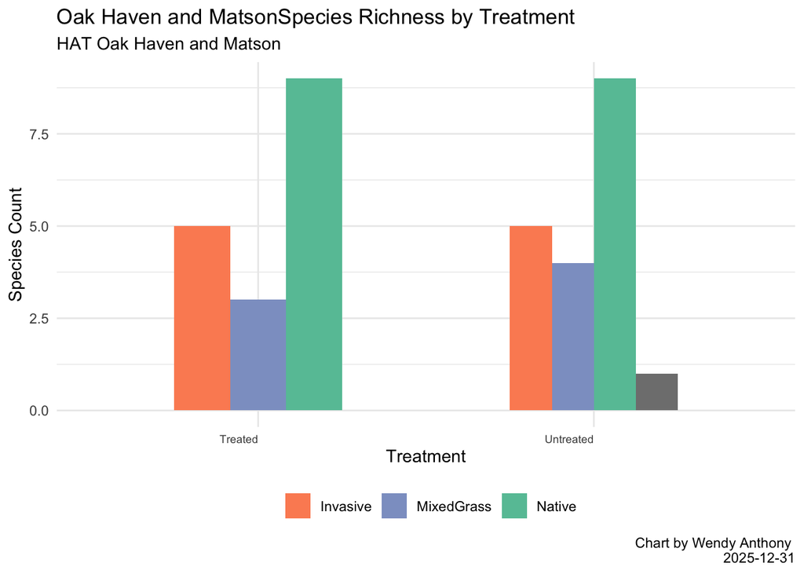

```r
# create custom colour-blind-friendly palette
custom_colours_3 <- c("Invasive" = "#fc8d62",
                    "Native" = "#66c2a5",
                    "MixedGrass" = "#8da0cb")
# custom_colours_3 <- c("Native" = "#1b9e77",
#                     "Invasive" = "#d95f02",
#                     "MixedGrass" = "#7570b3")

HAT_cover_mean_sp_rich_treat_plot <-
  ggplot(species_counts, aes(x = Treated, y = Species_number, fill = Native_or_Invasive)) +
  geom_bar(stat = "identity", width = 0.5, position = "dodge") +
  theme_minimal() + #get rid of grey background and tick marks
  theme(legend.position ="bottom") +
  theme(axis.text.x = element_text(angle = 0, vjust = 1, hjust=1, size = 7)) +
    scale_fill_manual(values = custom_colours_3) +
        labs(title='Oak Haven and MatsonSpecies Richness by Treatment',
          subtitle='HAT Oak Haven and Matson',
          caption = "Chart by Wendy Anthony \n 2025-12-31", fill = "",
          x = "Treatment", y = "Species Count")

HAT_cover_mean_sp_rich_treat_plot
```

```r
# ggplotly
  ggplotly(HAT_cover_mean_sp_rich_treat_plot)
```

[interactive chart not shown]

```r
# ggsave(filename = paste0("images/oakhaven_2025_sp_rich_treat_plot_", format(Sys.time(), "%Y-%m-%d_%H.%M"),".png"), oakhaven_2025_sp_rich_treat_plot)
```

## 4.6 ??? Function Mean Percent Cover

??? this isn’t resulting in any numbers

```r
#   col  <- data %>%
#   select(!(SortID:Native_or_Invasive))
#
# cols <- colnames(col)
#
# comma_separated_names <- paste(cols, collapse = ", ")


############################################################
############################################################
HAT_mean_cover_fun <- function(data, col_names) {
   data  <- data %>%
     group_by(Year, Date, Location, Treated, Species) %>%
     summarise(across(c(col_names), sum)) %>%
     # summarise(across(c(T_DL_Q1_4.3, T_DL_Q2_3.3, T_DL_Q3_8.3, T_CH_Q3_8.3, T_CH_Q1_4.3, T_CH_Q2_3.3), sum)) %>%
  # round
  mutate_if(is.numeric, round, 2)
}

# Error in UseMethod("group_by") :   no applicable method for 'group_by' applied to an object of class "function"

## Error in UseMethod("group_by") : no applicable method for 'group_by' applied to an object of class "character"
############################################################
############################################################









#   col  <- HAT_cover_OH_MM_sub_treat_OH_2025_wide %>%
#   select(!(SortID:Native_or_Invasive))
#
# cols <- colnames(HAT_cover_OH_MM_sub_treat_OH_2025_wide)
#
# comma_separated_names <- paste(cols, collapse = ", ")
# comma_separated_names
# #
#  colnames(HAT_cover_OH_MM_sub_treat_OH_2025_wide)
#  # test <- HAT_mean_cover_fun(HAT_cover_OH_MM_sub_treat_OH_2025_wide)
# #
#  test <- HAT_mean_cover_fun(HAT_cover_OH_MM_sub_treat_OH_2025_wide, "T_DL_Q1_4.3, T_DL_Q2_3.3, T_DL_Q3_8.3, T_CH_Q3_8.3, T_CH_Q1_4.3, T_CH_Q2_3.3")
```

# 5 Plots

## 5.1 CrewData-2022-2025

### 5.1.1 Oak Haven Park by Year

```r
str(crew_data_sep_sub_OHP)
```

```
## 'data.frame':    86 obs. of  10 variables:
##  $ Year                    : int  2022 2022 2022 2022 2022 2022 2022 2022 2022 2022 ...
##  $ Work_Site               : chr  "Oak Haven Park" "Oak Haven Park" "Oak Haven Park" "Oak Haven Park" ...
##  $ Area_Cleared_m2         : num  540 540 588 588 750 ...
##  $ Biomass_Removed_m3      : num  1.5 1.5 1.5 1.5 2 1.5 1.5 1.5 1.5 2 ...
##  $ Data_Change_Assumptions : chr  "estimate 1/2 of biomass, area, and work hours" "estimate 1/2 of biomass, area, and work hours" "estimate 1/2 of biomass, area, and work hours" "estimate 1/2 of biomass, area, and work hours" ...
##  $ Invasive_Species_Cleared: chr  "daphne" "Scotch broom" "daphne" "Scotch broom" ...
##  $ Native_or_Invasive      : chr  "Invasive" "Invasive" "Invasive" "Invasive" ...
##  $ Crew_Hours              : num  22.5 22.5 30 30 22.5 22.5 22.5 22.5 22.5 22.5 ...
##  $ Work_Volunteer          : chr  "Work" "Work" "Work" "Work" ...
##  $ Date                    : Date, format: "2022-09-07" "2022-09-07" ...
```

```r
colnames(crew_data_sep_sub_OHP)
```

```
##  [1] "Year"                     "Work_Site"
##  [3] "Area_Cleared_m2"          "Biomass_Removed_m3"
##  [5] "Data_Change_Assumptions"  "Invasive_Species_Cleared"
##  [7] "Native_or_Invasive"       "Crew_Hours"
##  [9] "Work_Volunteer"           "Date"
```

```r
unique(crew_data_sep_sub_OHP$Year) # 2023 2025 2024 2022
```

```
## [1] 2022 2023 2024 2025
```

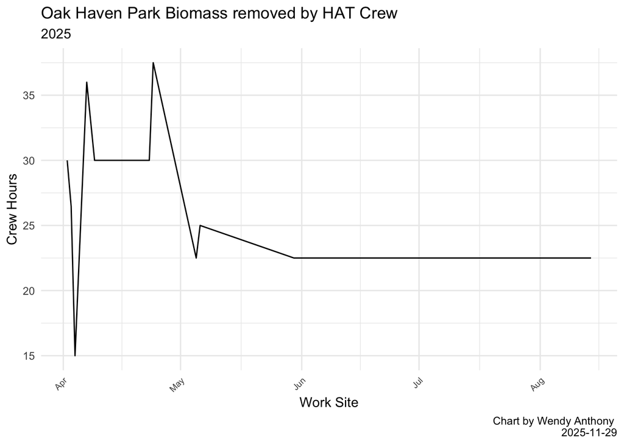

```r
# Filter by year - need column for year
crew_data_sep_sub_OHP_2025 <- crew_data_sep_sub_OHP[crew_data_sep_sub_OHP$Year == "2025",]
crew_data_sep_sub_OHP_2024 <- crew_data_sep_sub_OHP[crew_data_sep_sub_OHP$Year == "2024",]
crew_data_sep_sub_OHP_2023 <- crew_data_sep_sub_OHP[crew_data_sep_sub_OHP$Year == "2023",]
crew_data_sep_sub_OHP_2022 <- crew_data_sep_sub_OHP[crew_data_sep_sub_OHP$Year == "2022",]

crew_data_sep_sub_OHP_2025_plot <-
  ggplot(crew_data_sep_sub_OHP_2025, aes(x = Date, y = Crew_Hours, fill = Biomass_Removed_m3)) +
  #geom_bar(stat = "identity", width = 0.5, position = "dodge") +
  geom_line() +
  theme_minimal() + #get rid of grey background and tick marks
  theme(legend.position ="bottom") +
  theme(axis.text.x = element_text(angle = 45, vjust = 1, hjust=1, size = 7)) +
    #scale_fill_manual(values = custom_colours_3) +
        labs(title='Oak Haven Park Biomass removed by HAT Crew',
          subtitle='2025',
          caption = "Chart by Wendy Anthony \n 2025-11-29", fill = "Biomass_Removed_m3",
          x = "Work Site", y = "Crew Hours")

crew_data_sep_sub_OHP_2025_plot
```

```r
# ggsave(filename = paste0("images/crew_data_sep_sub_plot_W̱SÁNEĆ_", format(Sys.time(), "%Y-%m-%d_%H.%M"),".png"), crew_data_sep_sub_plot)
```

### 5.1.2 *** Total Biomass Removed Per Time Investment

- group and add up total crew hours and biomass removed

#### 5.1.2.1 Hours to Total Biomass Removed Ratio

```r
colnames(crew_data_sep_sub_sum_by_group_site_hr_bio_ratio)
```

```
## [1] "Work_Site"           "Year"                "Work_Volunteer"
## [4] "Biomass_Removed_m3"  "Crew_Hours"          "Area_Cleared_m2"
## [7] "Labour_Hr_Bio_Ratio" "Labour_Bio_Hr_Ratio" "Area_Bio_Ratio"
```

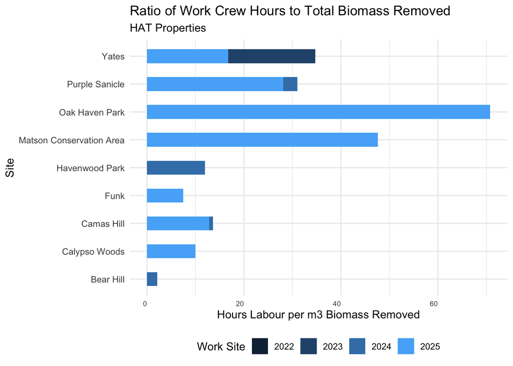

```r
crew_data_sep_hr_bio_ratio_by_group_site <- ggplot(crew_data_sep_sub_sum_by_group_site_hr_bio_ratio, aes(y = Work_Site, x = Labour_Hr_Bio_Ratio, fill = Year)) +
#  ggplot(crew_data_sep_sub_sum_by_group_site_2025, aes(x = Biomass_Removed_m3, y = Crew_Hours, fill = Work_Site)) +
  geom_bar(stat = "identity", width = 0.5, position = "dodge") +
  theme_minimal() + #get rid of grey background and tick marks
  theme(legend.position ="bottom") +
  theme(axis.text.x = element_text(angle = 0, vjust = 1, hjust=1, size = 7)) +
    #scale_fill_manual(values = custom_colours_3) +
        labs(title='Ratio of Work Crew Hours to Total Biomass Removed',
          subtitle='HAT Properties',
          # caption = "Chart by Wendy Anthony \n 2025-11-29",
          fill = "Year",
          y = "Site", x = "Hours Labour per m3 Biomass Removed") +
  guides(fill = guide_legend(title="Work Site"))
crew_data_sep_hr_bio_ratio_by_group_site
```

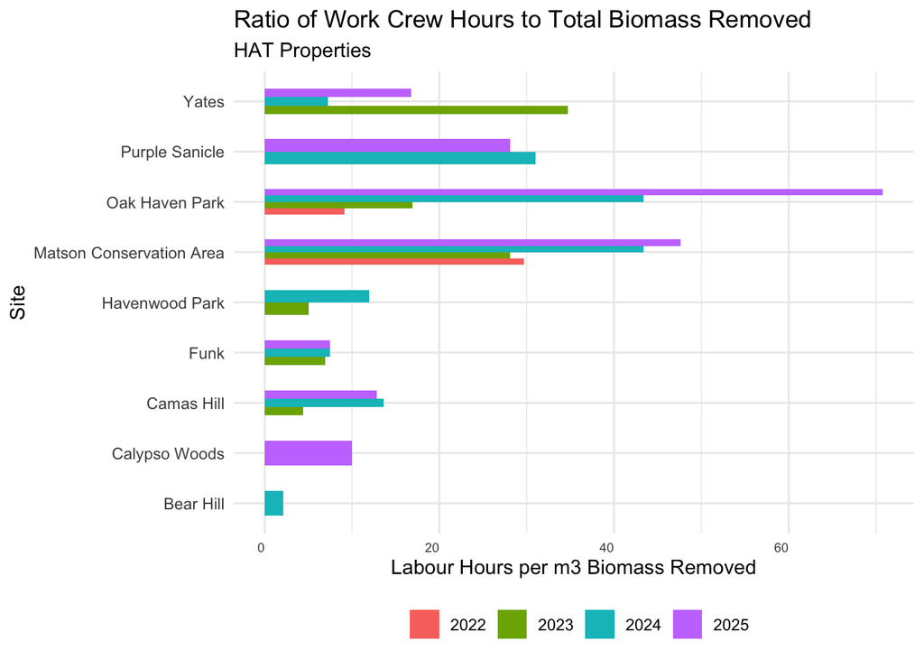

```r
crew_data_sep_hr_bio_ratio_by_group_site_rev <- ggplot(crew_data_sep_sub_sum_by_group_site_hr_bio_ratio, aes(y = as.factor(Work_Site), x = Labour_Hr_Bio_Ratio, fill = as.factor(Year))) +
#  ggplot(crew_data_sep_sub_sum_by_group_site_2025, aes(x = Biomass_Removed_m3, y = Crew_Hours, fill = Work_Site)) +
  geom_bar(stat = "identity", width = 0.5, position = "dodge") +
  theme_minimal() + #get rid of grey background and tick marks
  theme(legend.position ="bottom") +
  theme(axis.text.x = element_text(angle = 0, vjust = 1, hjust=1, size = 7)) +
    #scale_fill_manual(values = custom_colours_3) +
        labs(title='Ratio of Work Crew Hours to Total Biomass Removed',
          subtitle='HAT Properties',
          # caption = "Chart by Wendy Anthony \n 2025-11-29",
          fill = "Year",
          y = "Site", x = "Labour Hours per m3 Biomass Removed") +
  guides(fill = guide_legend(title=""))
crew_data_sep_hr_bio_ratio_by_group_site_rev
```

#### 5.1.2.2 Total Biomass Removed to Hours Ratio

```r
colnames(crew_data_sep_sub_sum_by_group_site_hr_bio_ratio)
```

```
## [1] "Work_Site"           "Year"                "Work_Volunteer"
## [4] "Biomass_Removed_m3"  "Crew_Hours"          "Area_Cleared_m2"
## [7] "Labour_Hr_Bio_Ratio" "Labour_Bio_Hr_Ratio" "Area_Bio_Ratio"
```

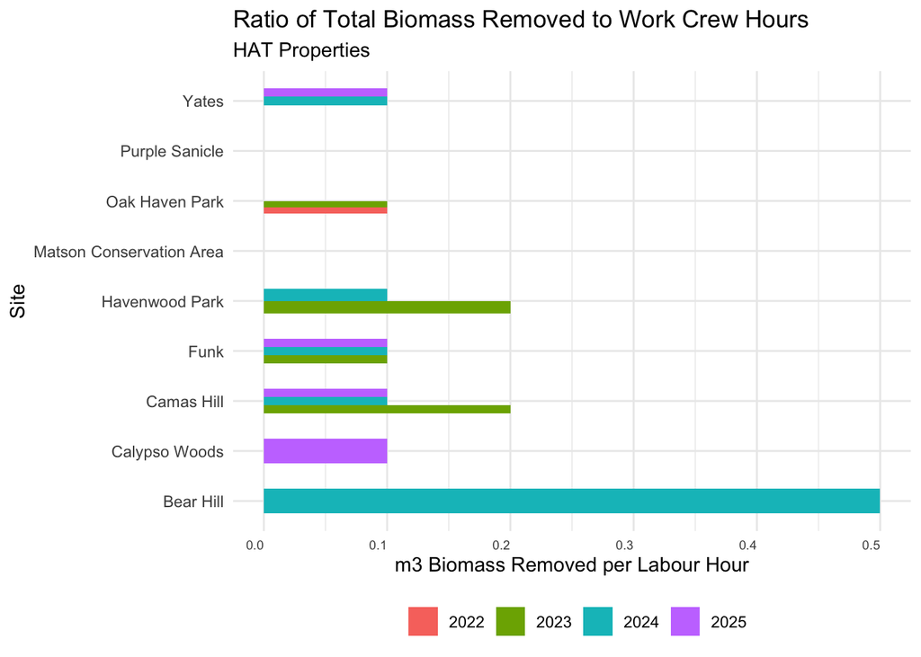

```r
crew_data_sep_bio_hr_ratio_by_group_site_rev <- ggplot(crew_data_sep_sub_sum_by_group_site_hr_bio_ratio, aes(y = as.factor(Work_Site), x = Labour_Bio_Hr_Ratio, fill = as.factor(Year))) +
#  ggplot(crew_data_sep_sub_sum_by_group_site_2025, aes(x = Biomass_Removed_m3, y = Crew_Hours, fill = Work_Site)) +
  geom_bar(stat = "identity", width = 0.5, position = "dodge") +
  theme_minimal() + #get rid of grey background and tick marks
  theme(legend.position ="bottom") +
  theme(axis.text.x = element_text(angle = 0, vjust = 1, hjust=1, size = 7)) +
    #scale_fill_manual(values = custom_colours_3) +
        labs(title='Ratio of Total Biomass Removed to Work Crew Hours',
          subtitle='HAT Properties',
          # caption = "Chart by Wendy Anthony \n 2025-11-29",
          fill = "Year",
          y = "Site", x = "m3 Biomass Removed per Labour Hour") +
  guides(fill = guide_legend(title=""))
crew_data_sep_bio_hr_ratio_by_group_site_rev
```

### 5.1.3 Biomass of Invasive Species

```r
colnames(crew_data_sep_sub_sum_bio_inv)
```

```
## [1] "Work_Site"                "Year"
## [3] "Invasive_Species_Cleared" "Data_Change_Assumptions"
## [5] "Work_Volunteer"           "Biomass_Removed_m3"
## [7] "Crew_Hours"               "Area_Cleared_m2"
```

```r
ggplotly(
  ggplot(crew_data_sep_sub_sum_bio_inv, aes(x = reorder(Invasive_Species_Cleared, desc(Invasive_Species_Cleared)), y = Biomass_Removed_m3, fill = as.factor(Year), text = paste("Year:", Year,
                                                          "\nSite:", Work_Site,
                                                          "\nCrew Hours:", Crew_Hours,
                                                          "\nBiomass Removed m3:", Biomass_Removed_m3,
                                                          "\nInvasive Species:", Invasive_Species_Cleared,
                                                          "\nArea Cleared m2:", Area_Cleared_m2))) +
#  ggplot(crew_data_sep_sub_sum_by_group_site_2025, aes(x = Biomass_Removed_m3, y = Crew_Hours, fill = Work_Site)) +
  geom_bar(stat = "identity", width = 0.5, position = "dodge") +
  coord_flip() +
  theme_minimal() + #get rid of grey background and tick marks
  theme(legend.position ="bottom") +
  theme(axis.text.x = element_text(angle = 0, vjust = 1, hjust=1, size = 7)) +
    #scale_fill_manual(values = custom_colours_3) +
        labs(title='Biomass Removed per Invasive Species',
          subtitle='HAT Properties',
          # caption = "Chart by Wendy Anthony \n 2025-11-29",
          fill = "Year",
          x = "Invasive Species", y = "m3 Biomass Removed") +
      theme(axis.text.x = element_text(angle = 0, vjust = 1, hjust = 1, size = 7)),
    # tooltip = c("x", "fill", "Species", "Site", "sd_value"),
    tooltip = "text",
  config = (displayModeBar = False)
  ) %>%
    layout(legend = list(orientation="h",
    xanchor="center",
    x = 0.5,
    # gives some space between x axis label and legend
    y = -0.2
    )
)
```

[interactive chart not shown]

### 5.1.4 Stacked Bar Biomass of Invasive Species

```r
colnames(crew_data_sep_sub_sum_bio_inv)
```

```
## [1] "Work_Site"                "Year"
## [3] "Invasive_Species_Cleared" "Data_Change_Assumptions"
## [5] "Work_Volunteer"           "Biomass_Removed_m3"
## [7] "Crew_Hours"               "Area_Cleared_m2"
```

```r
ggplotly(
  ggplot(crew_data_sep_sub_sum_bio_inv, aes(x = reorder(Invasive_Species_Cleared, desc(Invasive_Species_Cleared)), y = Biomass_Removed_m3, fill = as.factor(Year), text = paste("Year:", Year,
                                                          "\nSite:", Work_Site,
                                                          "\nCrew Hours:", Crew_Hours,
                                                          "\nBiomass Removed m3:", Biomass_Removed_m3,
                                                          "\nInvasive Species:", Invasive_Species_Cleared,
                                                          "\nArea Cleared m2:", Area_Cleared_m2))) +
#  ggplot(crew_data_sep_sub_sum_by_group_site_2025, aes(x = Biomass_Removed_m3, y = Crew_Hours, fill = Work_Site)) +
  geom_bar(stat = "identity", width = 0.5) +
  coord_flip() +
  theme_minimal() + #get rid of grey background and tick marks
  theme(legend.position ="bottom") +
  theme(axis.text.x = element_text(angle = 0, vjust = 1, hjust=1, size = 7)) +
    #scale_fill_manual(values = custom_colours_3) +
        labs(title='Biomass Removed per Invasive Species',
          subtitle='HAT Properties',
          # caption = "Chart by Wendy Anthony \n 2025-11-29",
          fill = "Year",
          x = "Invasive Species", y = "m3 Biomass Removed") +
      theme(axis.text.x = element_text(angle = 0, vjust = 1, hjust = 1, size = 7)),
    # tooltip = c("x", "fill", "Species", "Site", "sd_value"),
    tooltip = "text",
  config = (displayModeBar = False)
  ) %>%
    layout(legend = list(orientation="h",
    xanchor="center",
    x = 0.5,
    # gives some space between x axis label and legend
    y = -0.2
    )
)
```

[interactive chart not shown]

#### 5.1.4.1 2025

```r
colnames(crew_data_sep_sub_sum_by_group_site_hr_bio_ratio)
```

```
## [1] "Work_Site"           "Year"                "Work_Volunteer"
## [4] "Biomass_Removed_m3"  "Crew_Hours"          "Area_Cleared_m2"
## [7] "Labour_Hr_Bio_Ratio" "Labour_Bio_Hr_Ratio" "Area_Bio_Ratio"
```

```r
# [1] "Work_Site"          "Year"               "Biomass_Removed_m3" "Crew_Hours"

unique(crew_data_sep_sub_sum_by_group_site_hr_bio_ratio$Work_Site)
```

```
## [1] "Bear Hill"                "Calypso Woods"
## [3] "Camas Hill"               "Funk"
## [5] "Havenwood Park"           "Matson Conservation Area"
## [7] "Oak Haven Park"           "Purple Sanicle"
## [9] "Yates"
```

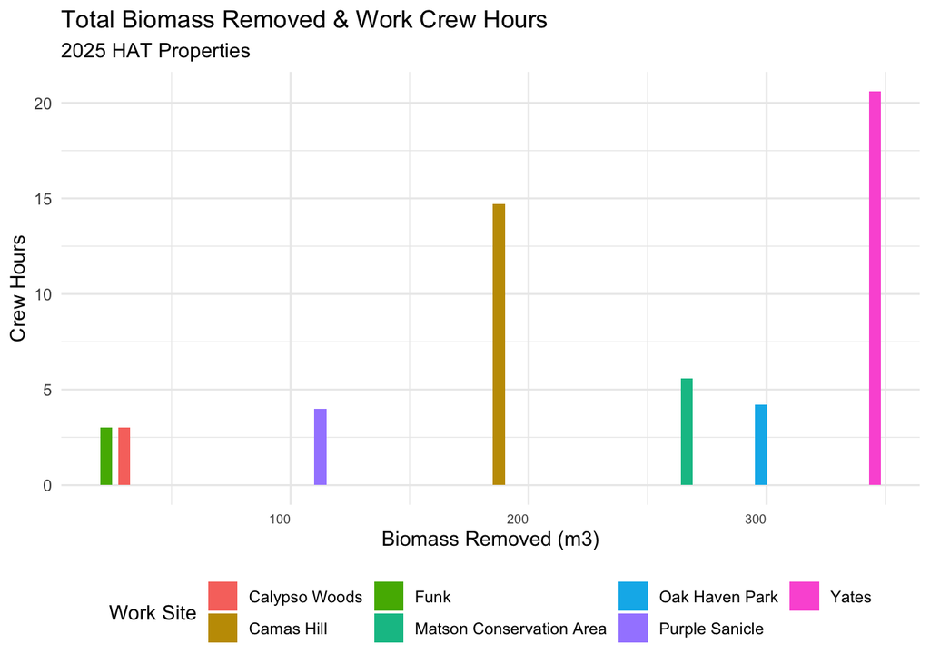

```r
# Filter by year - need column for year
crew_data_sep_sub_sum_by_group_site_hr_bio_ratio_2025 <- crew_data_sep_sub_sum_by_group_site_hr_bio_ratio[crew_data_sep_sub_sum_by_group_site_hr_bio_ratio$Year == "2025",]

crew_data_sep_sub_sum_by_group_site_hr_bio_ratio_2025_plot <-
  ggplot(crew_data_sep_sub_sum_by_group_site_hr_bio_ratio_2025, aes(x = Crew_Hours, y = Biomass_Removed_m3, fill = Work_Site)) +
#  ggplot(crew_data_sep_sub_sum_by_group_site_2025, aes(x = Biomass_Removed_m3, y = Crew_Hours, fill = Work_Site)) +
  geom_bar(stat = "identity", width = 5, position = "dodge") +
  theme_minimal() + #get rid of grey background and tick marks
  theme(legend.position ="bottom") +
  theme(axis.text.x = element_text(angle = 0, vjust = 1, hjust=1, size = 7)) +
    #scale_fill_manual(values = custom_colours_3) +
        labs(title='Total Biomass Removed & Work Crew Hours',
          subtitle='2025 HAT Properties',
          # caption = "Chart by Wendy Anthony \n 2025-11-29",
          fill = "Work_Site",
          x = "Biomass Removed (m3)", y = "Crew Hours") +
  guides(fill = guide_legend(title="Work Site"))

crew_data_sep_sub_sum_by_group_site_hr_bio_ratio_2025_plot
```

```r
# ggsave(filename = paste0("images/crew_data_sep_sub_2025_plotĆ_", format(Sys.time(), "%Y-%m-%d_%H.%M"),".png"), crew_data_sep_sub_2025_plot)
```

#### 5.1.4.2 2024

```r
colnames(crew_data_sep_sub_sum_by_group_site_hr_bio_ratio)
```

```
## [1] "Work_Site"           "Year"                "Work_Volunteer"
## [4] "Biomass_Removed_m3"  "Crew_Hours"          "Area_Cleared_m2"
## [7] "Labour_Hr_Bio_Ratio" "Labour_Bio_Hr_Ratio" "Area_Bio_Ratio"
```

```r
# [1] "Work_Site"          "Year"               "Biomass_Removed_m3" "Crew_Hours"

unique(crew_data_sep_sub_sum_by_group_site_hr_bio_ratio$Work_Site)
```

```
## [1] "Bear Hill"                "Calypso Woods"
## [3] "Camas Hill"               "Funk"
## [5] "Havenwood Park"           "Matson Conservation Area"
## [7] "Oak Haven Park"           "Purple Sanicle"
## [9] "Yates"
```

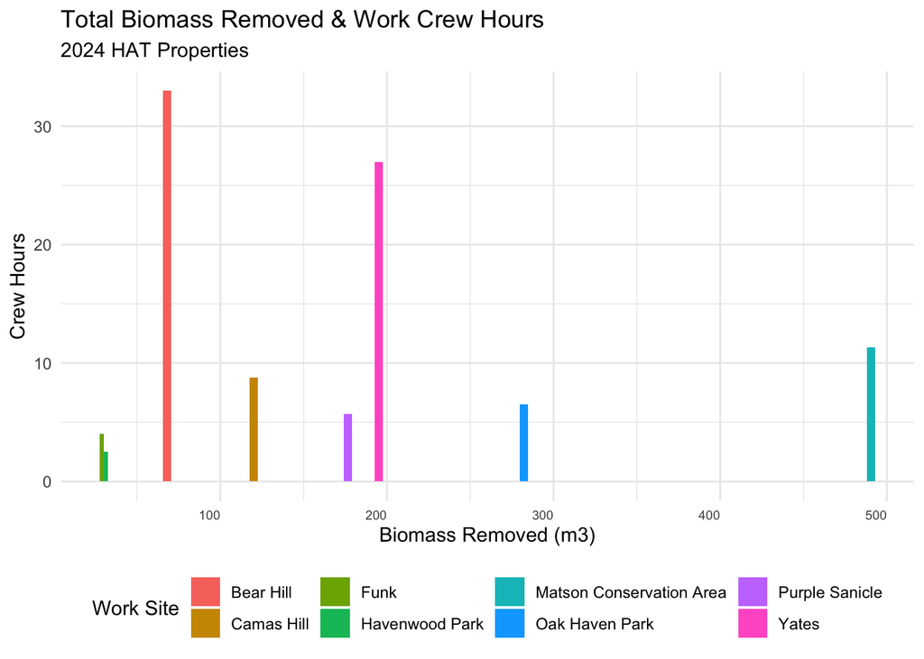

```r
# Filter by year - need column for year
crew_data_sep_sub_sum_by_group_site_hr_bio_ratio_2024 <- crew_data_sep_sub_sum_by_group_site_hr_bio_ratio[crew_data_sep_sub_sum_by_group_site_hr_bio_ratio$Year == "2024",]

crew_data_sep_sub_sum_by_group_site_hr_bio_ratio_2024_plot <-
  ggplot(crew_data_sep_sub_sum_by_group_site_hr_bio_ratio_2024, aes(x = Crew_Hours, y = Biomass_Removed_m3, fill = Work_Site)) +
#  ggplot(crew_data_sep_sub_sum_by_group_site_2025, aes(x = Biomass_Removed_m3, y = Crew_Hours, fill = Work_Site)) +
  geom_bar(stat = "identity", width = 5, position = "dodge") +
  theme_minimal() + #get rid of grey background and tick marks
  theme(legend.position ="bottom") +
  theme(axis.text.x = element_text(angle = 0, vjust = 1, hjust=1, size = 7)) +
    #scale_fill_manual(values = custom_colours_3) +
        labs(title='Total Biomass Removed & Work Crew Hours',
          subtitle='2024 HAT Properties',
          #caption = "Chart by Wendy Anthony \n 2025-11-29",
          fill = "Work_Site",
          x = "Biomass Removed (m3)", y = "Crew Hours") +
  guides(fill = guide_legend(title="Work Site"))

crew_data_sep_sub_sum_by_group_site_hr_bio_ratio_2024_plot
```

```r
# ggsave(filename = paste0("images/crew_data_sep_sub_sum_by_group_site_hr_bio_ratio_2024_plot_", format(Sys.time(), "%Y-%m-%d_%H.%M"),".png"), crew_data_sep_sub_sum_by_group_site_hr_bio_ratio_2024_plot)
```

#### 5.1.4.3 2023

```r
colnames(crew_data_sep_sub_sum_by_group_site_hr_bio_ratio)
```

```
## [1] "Work_Site"           "Year"                "Work_Volunteer"
## [4] "Biomass_Removed_m3"  "Crew_Hours"          "Area_Cleared_m2"
## [7] "Labour_Hr_Bio_Ratio" "Labour_Bio_Hr_Ratio" "Area_Bio_Ratio"
```

```r
# [1] "Work_Site"          "Year"               "Biomass_Removed_m3" "Crew_Hours"

unique(crew_data_sep_sub_sum_by_group_site_hr_bio_ratio$Work_Site)
```

```
## [1] "Bear Hill"                "Calypso Woods"
## [3] "Camas Hill"               "Funk"
## [5] "Havenwood Park"           "Matson Conservation Area"
## [7] "Oak Haven Park"           "Purple Sanicle"
## [9] "Yates"
```

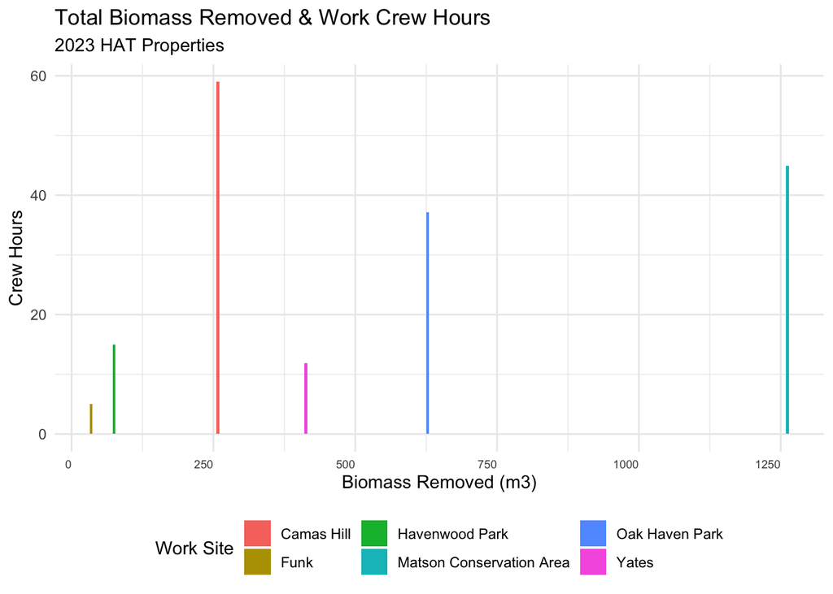

```r
# Filter by year - need column for year
crew_data_sep_sub_sum_by_group_site_hr_bio_ratio_2023 <- crew_data_sep_sub_sum_by_group_site_hr_bio_ratio[crew_data_sep_sub_sum_by_group_site_hr_bio_ratio$Year == "2023",]

crew_data_sep_sub_sum_by_group_site_hr_bio_ratio_2023_plot <-
  ggplot(crew_data_sep_sub_sum_by_group_site_hr_bio_ratio_2023, aes(x = Crew_Hours, y = Biomass_Removed_m3, fill = Work_Site)) +
#  ggplot(crew_data_sep_sub_sum_by_group_site_2025, aes(x = Biomass_Removed_m3, y = Crew_Hours, fill = Work_Site)) +
  geom_bar(stat = "identity", width = 5, position = "dodge") +
  theme_minimal() + #get rid of grey background and tick marks
  theme(legend.position ="bottom") +
  theme(axis.text.x = element_text(angle = 0, vjust = 1, hjust=1, size = 7)) +
    #scale_fill_manual(values = custom_colours_3) +
        labs(title='Total Biomass Removed & Work Crew Hours',
          subtitle='2023 HAT Properties',
          #caption = "Chart by Wendy Anthony \n 2025-11-29",
          fill = "Work_Site",
          x = "Biomass Removed (m3)", y = "Crew Hours") +
  guides(fill = guide_legend(title="Work Site"))

crew_data_sep_sub_sum_by_group_site_hr_bio_ratio_2023_plot
```

```r
# ggsave(filename = paste0("images/crew_data_sep_sub_sum_by_group_site_hr_bio_ratio_2023_plot_", format(Sys.time(), "%Y-%m-%d_%H.%M"),".png"), crew_data_sep_sub_sum_by_group_site_hr_bio_ratio_2023_plot)
```

#### 5.1.4.4 2022

```r
colnames(crew_data_sep_sub_sum_by_group_site_hr_bio_ratio)
```

```
## [1] "Work_Site"           "Year"                "Work_Volunteer"
## [4] "Biomass_Removed_m3"  "Crew_Hours"          "Area_Cleared_m2"
## [7] "Labour_Hr_Bio_Ratio" "Labour_Bio_Hr_Ratio" "Area_Bio_Ratio"
```

```r
# [1] "Work_Site"          "Year"               "Biomass_Removed_m3" "Crew_Hours"

unique(crew_data_sep_sub_sum_by_group_site_hr_bio_ratio$Work_Site)
```

```
## [1] "Bear Hill"                "Calypso Woods"
## [3] "Camas Hill"               "Funk"
## [5] "Havenwood Park"           "Matson Conservation Area"
## [7] "Oak Haven Park"           "Purple Sanicle"
## [9] "Yates"
```

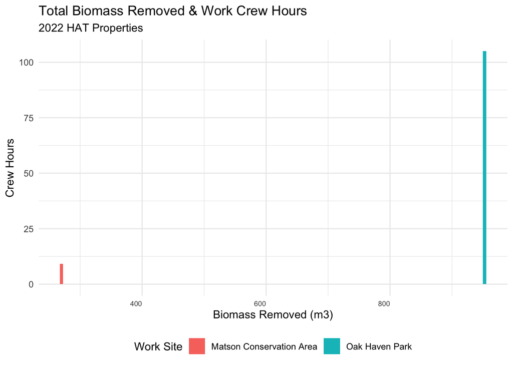

```r
# Filter by year - need column for year
crew_data_sep_sub_sum_by_group_site_hr_bio_ratio_2022 <- crew_data_sep_sub_sum_by_group_site_hr_bio_ratio[crew_data_sep_sub_sum_by_group_site_hr_bio_ratio$Year == "2022",]

crew_data_sep_sub_sum_by_group_site_hr_bio_ratio_2022_plot <-
  ggplot(crew_data_sep_sub_sum_by_group_site_hr_bio_ratio_2022, aes(x = Crew_Hours, y = Biomass_Removed_m3, fill = Work_Site)) +
#  ggplot(crew_data_sep_sub_sum_by_group_site_2025, aes(x = Biomass_Removed_m3, y = Crew_Hours, fill = Work_Site)) +
  geom_bar(stat = "identity", width = 5, position = "dodge") +
  theme_minimal() + #get rid of grey background and tick marks
  theme(legend.position ="bottom") +
  theme(axis.text.x = element_text(angle = 0, vjust = 1, hjust=1, size = 7)) +
    #scale_fill_manual(values = custom_colours_3) +
        labs(title='Total Biomass Removed & Work Crew Hours',
          subtitle='2022 HAT Properties',
          #caption = "Chart by Wendy Anthony \n 2025-11-29",
          fill = "Work_Site",
          x = "Biomass Removed (m3)", y = "Crew Hours") +
  guides(fill = guide_legend(title="Work Site"))

crew_data_sep_sub_sum_by_group_site_hr_bio_ratio_2022_plot
```

```r
# ggsave(filename = paste0("images/crew_data_sep_sub_sum_by_group_site_hr_bio_ratio_2022_", format(Sys.time(), "%Y-%m-%d_%H.%M"),".png"), crew_data_sep_sub_sum_by_group_site_hr_bio_ratio_2022)
```

#### 5.1.4.5 *** Facet wrap 2022-2025

```r
colnames(crew_data_sep_sub_sum_by_group_site_hr_bio_ratio)
```

```
## [1] "Work_Site"           "Year"                "Work_Volunteer"
## [4] "Biomass_Removed_m3"  "Crew_Hours"          "Area_Cleared_m2"
## [7] "Labour_Hr_Bio_Ratio" "Labour_Bio_Hr_Ratio" "Area_Bio_Ratio"
```

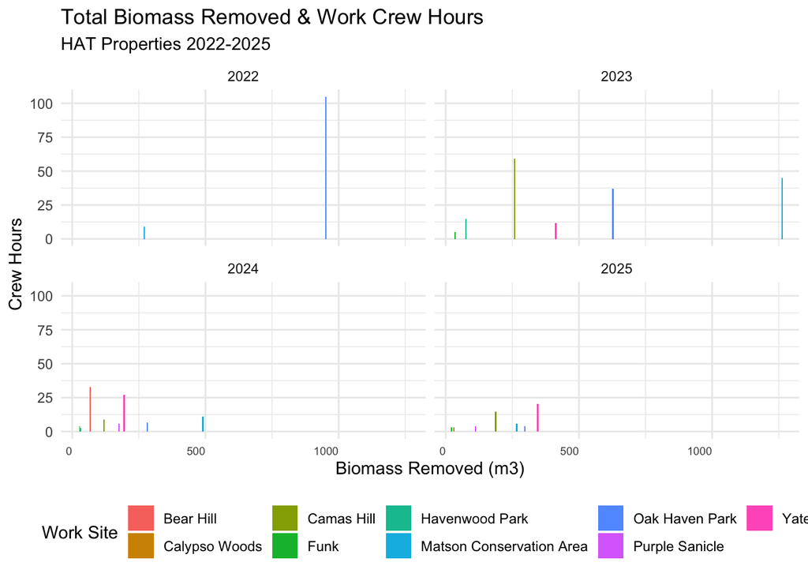

```r
# [1] "Work_Site"          "Year"               "Biomass_Removed_m3" "Crew_Hours"

# unique(crew_data_sep_sub_sum_by_group_site$Work_Site)
# Filter by year - need column for year
# crew_data_sep_sub_sum_by_group_site_2022 <- crew_data_sep_sub_sum_by_group_site[crew_data_sep_sub_sum_by_group_site$Year == "2022",]

crew_data_sep_sub_sum_by_group_site_hr_bio_ratio_plot_facetwrap_2022_2025 <-
  ggplot(crew_data_sep_sub_sum_by_group_site_hr_bio_ratio, aes(x = Crew_Hours, y = Biomass_Removed_m3, fill = Work_Site)) +
#  ggplot(crew_data_sep_sub_sum_by_group_site_2025, aes(x = Biomass_Removed_m3, y = Crew_Hours, fill = Work_Site)) +
  geom_bar(stat = "identity", width = 5, position = "dodge") +
  facet_wrap(~Year) +
  theme_minimal() + #get rid of grey background and tick marks
  theme(legend.position ="bottom") +
  theme(axis.text.x = element_text(angle = 0, vjust = 1, hjust=1, size = 7)) +
    #scale_fill_manual(values = custom_colours_3) +
        labs(title='Total Biomass Removed & Work Crew Hours',
          subtitle='HAT Properties 2022-2025',
          #caption = "Chart by Wendy Anthony \n 2025-11-29",
          fill = "Work_Site",
          x = "Biomass Removed (m3)", y = "Crew Hours") +
  guides(fill = guide_legend(title="Work Site"))

crew_data_sep_sub_sum_by_group_site_hr_bio_ratio_plot_facetwrap_2022_2025
```

```r
# ggsave(filename = paste0("images/crew_data_sep_sub_sum_by_group_site_plot_facetwrap_2022_2025_plot_", format(Sys.time(), "%Y-%m-%d_%H.%M"),".png"), crew_data_sep_sub_sum_by_group_site_plot_facetwrap_2022_2025)
```

#### 5.1.4.6 **** FUNCTION for Total Biomass and Year WORKED!!!

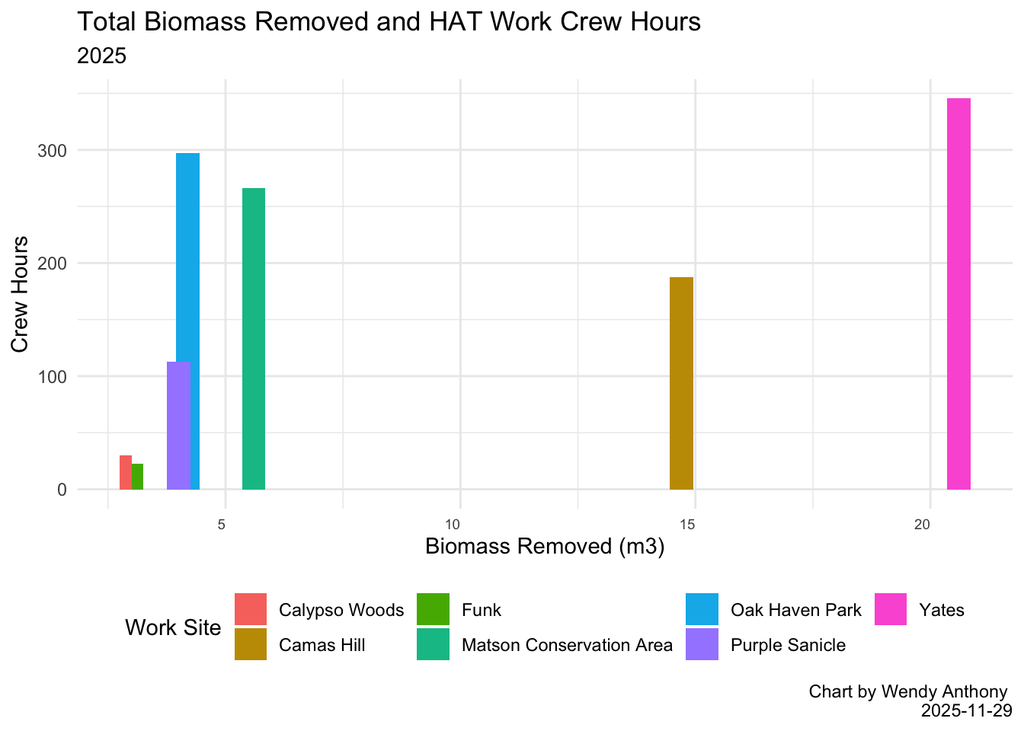

```
## # A tibble: 7 × 9
## # Groups:   Work_Site, Year [7]
##   Work_Site    Year Work_Volunteer Biomass_Removed_m3 Crew_Hours Area_Cleared_m2
##   <chr>       <int> <chr>                       <dbl>      <dbl>           <dbl>
## 1 Calypso Wo…  2025 Work                          3         30              595.
## 2 Camas Hill   2025 Work                         14.7      188.            4986.
## 3 Funk         2025 Work                          3         22.5           5345.
## 4 Matson Con…  2025 Work                          5.6      266.            1300.
## 5 Oak Haven …  2025 Work                          4.2      298.            1035.
## 6 Purple San…  2025 Work                          4        112.            1038.
## 7 Yates        2025 Work                         20.6      346.           12137.
## # ℹ 3 more variables: Labour_Hr_Bio_Ratio <dbl>, Labour_Bio_Hr_Ratio <dbl>,
## #   Area_Bio_Ratio <dbl>
```

```r
barchart_work_site_biomass_year_function <- function(data, filter_column, filter_value, plot_subtitle = "Filtered Plot", plot_ojbect){
  filtered_data <- data %>%
     filter({{filter_column}} == filter_value)

plot_ojbect <- ggplot(filtered_data, aes(x = Biomass_Removed_m3, y = Crew_Hours, fill = Work_Site)) +
#  ggplot(crew_data_sep_sub_sum_by_group_site_2025, aes(x = Biomass_Removed_m3, y = Crew_Hours, fill = Work_Site)) +
  geom_bar(stat = "identity", width = 0.5, position = "dodge") +
  theme_minimal() + #get rid of grey background and tick marks
  theme(legend.position ="bottom") +
  theme(axis.text.x = element_text(angle = 0, vjust = 1, hjust=1, size = 7)) +
    #scale_fill_manual(values = custom_colours_3) +
        labs(title = 'Total Biomass Removed and HAT Work Crew Hours',
          subtitle = plot_subtitle,
          caption = "Chart by Wendy Anthony \n 2025-11-29", fill = "Work_Site",
          x = "Biomass Removed (m3)", y = "Crew Hours") +
  guides(fill = guide_legend(title="Work Site"))
print(plot_ojbect)
return(filtered_data)
# ?? print(barchart_work_site_biomass_year_function(crew_data_sep_sub_sum_by_group_site))
}

# this returns a list
# biomass_2025 <- barchart_work_site_biomass_year_function(crew_data_sep_sub_sum_by_group_site, Year, "2025", "2025", "biomass_2025")
barchart_work_site_biomass_year_function(crew_data_sep_sub_sum_by_group_site_hr_bio_ratio, Year, "2025", "2025", "biomass_2025")
```

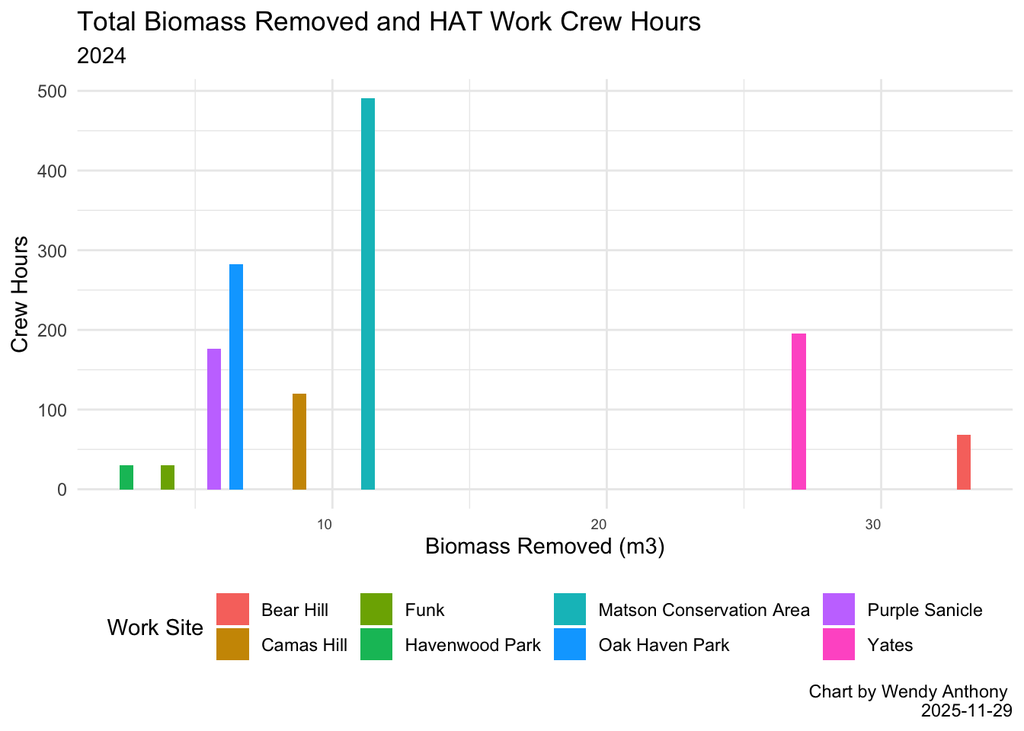

```
## # A tibble: 8 × 9
## # Groups:   Work_Site, Year [8]
##   Work_Site    Year Work_Volunteer Biomass_Removed_m3 Crew_Hours Area_Cleared_m2
##   <chr>       <int> <chr>                       <dbl>      <dbl>           <dbl>
## 1 Bear Hill    2024 Work                         33          68             729
## 2 Camas Hill   2024 Work                          8.8       120             842.
## 3 Funk         2024 Work                          4          30            3549
## 4 Havenwood …  2024 Work                          2.5        30             342
## 5 Matson Con…  2024 Work                         11.3       490.           3342.
## 6 Oak Haven …  2024 Work                          6.5       282            1041
## 7 Purple San…  2024 Work                          5.7       176.            656.
## 8 Yates        2024 Work                         27         195           15621
## # ℹ 3 more variables: Labour_Hr_Bio_Ratio <dbl>, Labour_Bio_Hr_Ratio <dbl>,
## #   Area_Bio_Ratio <dbl>
```

```r
barchart_work_site_biomass_year_function(crew_data_sep_sub_sum_by_group_site_hr_bio_ratio, Year, "2024", "2024", "biomass_2024")
```

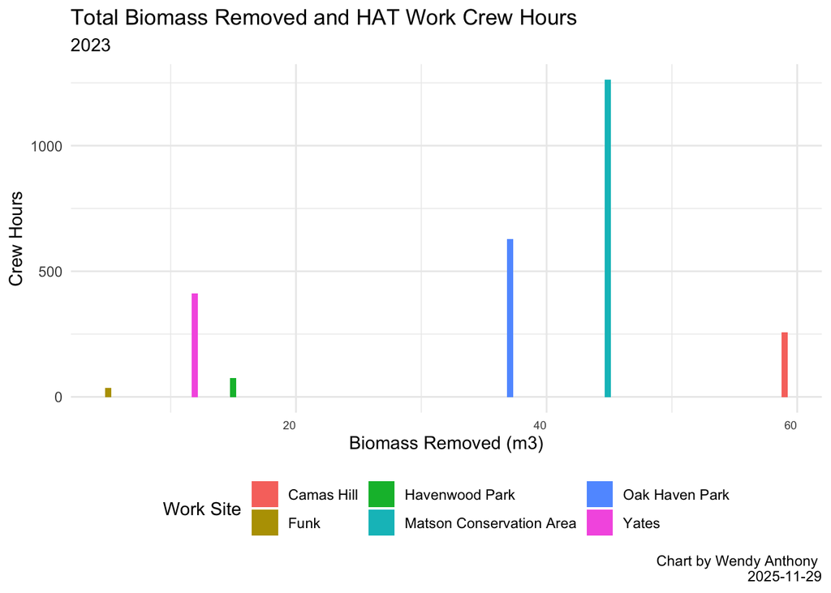

```
## # A tibble: 6 × 9
## # Groups:   Work_Site, Year [6]
##   Work_Site    Year Work_Volunteer Biomass_Removed_m3 Crew_Hours Area_Cleared_m2
##   <chr>       <int> <chr>                       <dbl>      <dbl>           <dbl>
## 1 Camas Hill   2023 Work                         59        258             2800
## 2 Funk         2023 Work                          5         34.5           1513
## 3 Havenwood …  2023 Work                         15         75              200
## 4 Matson Con…  2023 Work                         44.9     1262             1531.
## 5 Oak Haven …  2023 Work                         37.1      628.            2880.
## 6 Yates        2023 Work                         11.9      413            47222
## # ℹ 3 more variables: Labour_Hr_Bio_Ratio <dbl>, Labour_Bio_Hr_Ratio <dbl>,
## #   Area_Bio_Ratio <dbl>
```

```r
barchart_work_site_biomass_year_function(crew_data_sep_sub_sum_by_group_site_hr_bio_ratio, Year, "2023", "2023", "biomass_2023")
```

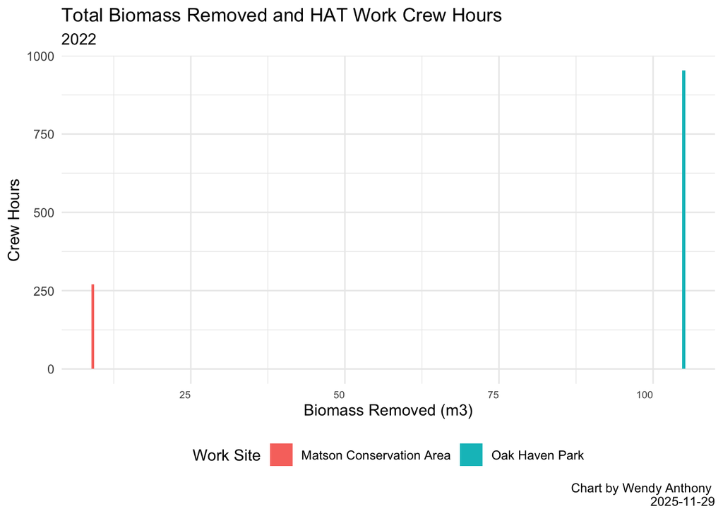

```
## # A tibble: 2 × 9
## # Groups:   Work_Site, Year [2]
##   Work_Site    Year Work_Volunteer Biomass_Removed_m3 Crew_Hours Area_Cleared_m2
##   <chr>       <int> <chr>                       <dbl>      <dbl>           <dbl>
## 1 Matson Con…  2022 Work                          9.1       270             335
## 2 Oak Haven …  2022 Work                        105         952.          17355.
## # ℹ 3 more variables: Labour_Hr_Bio_Ratio <dbl>, Labour_Bio_Hr_Ratio <dbl>,
## #   Area_Bio_Ratio <dbl>
```

```r
barchart_work_site_biomass_year_function(crew_data_sep_sub_sum_by_group_site_hr_bio_ratio, Year, "2022", "2022", "biomass_2022")
```

```r
#
# # barchart_work_site_biomass_year <- function(data, filter_column, filter_value, x_var, y_var, plot_title = "Filtered Plot"){
# # # unique(crew_data_sep_sub_sum_by_group_site$Work_Site)
# #
# # # Filter by year - need column for year
# #   filtered_data <- data %>%
# #     filter({{filter_column}} == filter_value)
# #
# #   p <- ggplot(filtered_data, aes(x = .data[[x_var]], y = .data[[y_var]])) +
# #     geom_bar(stat = "identity", width = 5, position = "dodge") +
# #     labs(title = plot_title,
# #          x = x_var,
# #          y = y_var) +
# #     theme_minimal()
# #
# #   return(p)
# #
# #  }
#
# ### ERROR IN FILTER
# # In argument: `crew_data_sep_sub_sum_by_group_site$Year == filter_value`.
# # ℹ In group 1: `Work_Site = "Bear Hill"`.
# # Caused by error:
# # ! `..1` must be of size 1, not size 23.
# # colnames(crew_data_sep_sub_sum_by_group_site)
# # unique(crew_data_sep_sub_sum_by_group_site$Work_Site)
# # barchart_work_site_biomass_year(crew_data_sep_sub_sum_by_group_site, crew_data_sep_sub_sum_by_group_site$Work_Site, "2024", crew_data_sep_sub_sum_by_group_site$Biomass_Removed_m3, crew_data_sep_sub_sum_by_group_site$Crew_Hours, "Total Biomass Removed and Work Crew Hours")
#
# # barchart_work_site_biomass_year(crew_data_sep_sub_sum_by_group_site, crew_data_sep_sub_sum_by_group_site$Work_Site, "Oak Haven Park", crew_data_sep_sub_sum_by_group_site$Biomass_Removed_m3, crew_data_sep_sub_sum_by_group_site$Crew_Hours, "Total Biomass Removed and Work Crew Hours at Oak Haven Park")
```

### 5.1.5 Arrange charts together

- can’t arrange charts created with function
- need to use same x & y axis limits so charts are comparable
- ??? can I share Title and legend???

[figure not shown]

```r
library(cowplot)
plot_grid(crew_data_sep_sub_sum_by_group_site_hr_bio_ratio_2025_plot, crew_data_sep_sub_sum_by_group_site_hr_bio_ratio_2024_plot,
crew_data_sep_sub_sum_by_group_site_hr_bio_ratio_2023_plot,
crew_data_sep_sub_sum_by_group_site_hr_bio_ratio_2022, ncol = 4)
```

```r
# , labels = c("2025", "2024", "2023", "2022")


# Warning in as_grob.default(plot) :
#  Cannot convert object of class grouped_dftbl_dftbldata.frame into a grob.
# plot_grid(barchart_work_site_biomass_year_function(crew_data_sep_sub_sum_by_group_site, Year, "2025", "2025", "biomass_2025"), barchart_work_site_biomass_year_function(crew_data_sep_sub_sum_by_group_site, Year, "2024", "2024", "biomass_2024"), barchart_work_site_biomass_year_function(crew_data_sep_sub_sum_by_group_site, Year, "2023", "2023", "biomass_2023"), barchart_work_site_biomass_year_function(crew_data_sep_sub_sum_by_group_site, Year, "2022", "2022", "biomass_2022"), ncol = 2)
```

### 5.1.6 Biomass Removed

```r
str(crew_data_sep_sub)
```

```
## 'data.frame':    238 obs. of  10 variables:
##  $ Year                    : int  2022 2022 2022 2022 2022 2022 2022 2022 2022 2022 ...
##  $ Work_Site               : chr  "Oak Haven Park" "Oak Haven Park" "Oak Haven Park" "Oak Haven Park" ...
##  $ Area_Cleared_m2         : num  540 540 588 588 750 ...
##  $ Biomass_Removed_m3      : num  1.5 1.5 1.5 1.5 2 1.5 1.5 1.5 1.5 2 ...
##  $ Data_Change_Assumptions : chr  "estimate 1/2 of biomass, area, and work hours" "estimate 1/2 of biomass, area, and work hours" "estimate 1/2 of biomass, area, and work hours" "estimate 1/2 of biomass, area, and work hours" ...
##  $ Invasive_Species_Cleared: chr  "daphne" "Scotch broom" "daphne" "Scotch broom" ...
##  $ Native_or_Invasive      : chr  "Invasive" "Invasive" "Invasive" "Invasive" ...
##  $ Crew_Hours              : num  22.5 22.5 30 30 22.5 22.5 22.5 22.5 22.5 22.5 ...
##  $ Work_Volunteer          : chr  "Work" "Work" "Work" "Work" ...
##  $ Date                    : Date, format: "2022-09-07" "2022-09-07" ...
```

```r
colnames(crew_data_sep_sub)
```

```
##  [1] "Year"                     "Work_Site"
##  [3] "Area_Cleared_m2"          "Biomass_Removed_m3"
##  [5] "Data_Change_Assumptions"  "Invasive_Species_Cleared"
##  [7] "Native_or_Invasive"       "Crew_Hours"
##  [9] "Work_Volunteer"           "Date"
```

[figure not shown]

```r
# create custom colour-blind-friendly palette
custom_colours_3 <- c("Invasive" = "#fc8d62",
                    "Native" = "#66c2a5",
                    "MixedGrass" = "#8da0cb")
# custom_colours_3 <- c("Native" = "#1b9e77",
#                     "Invasive" = "#d95f02",
#                     "MixedGrass" = "#7570b3")

crew_data_sep_sub_plot <-
  ggplot(crew_data_sep_sub, aes(x = Work_Site, y = Crew_Hours, fill = Biomass_Removed_m3)) +
  geom_bar(stat = "identity", width = 0.5, position = "dodge") +
  theme_minimal() + #get rid of grey background and tick marks
  theme(legend.position ="bottom") +
  theme(axis.text.x = element_text(angle = 45, vjust = 1, hjust=1, size = 7)) +
    #scale_fill_manual(values = custom_colours_3) +
        labs(title='Biomass removed',
          subtitle='2025 HAT Properties',
          caption = "Chart by Wendy Anthony \n 2025-11-29", fill = "Biomass_Removed_m3",
          x = "Work Site", y = "Crew Hours")

crew_data_sep_sub_plot
```

```r
# ggsave(filename = paste0("images/crew_data_sep_sub_plot_W̱SÁNEĆ_", format(Sys.time(), "%Y-%m-%d_%H.%M"),".png"), crew_data_sep_sub_plot)
```

## 5.2 Cover Data Plots

# 6 Leaflet Maps

## 6.1 3-Site Map

```r
# library(dplyr)
library(leaflet)

# Title control
# (Shackelford, et al., 2024). Global Restore Project. Restoration Futures Lab at the University of Victoria
     title <- '<p style="text-align: center; height: 18px; "><img src="https://images.squarespace-cdn.com/content/v1/5e3c5b7e5460c55405a6d4d6/a8c2fb30-96fd-4042-925f-e76c7040dce6/Black+Logo+2.png?format=5w"><span style="font-size:9px;font-weight:bold; background-color: rgba(255, 255, 255, 0.9;");>GOE Monitoring Covenant Sites Map</span></p>'

    # https://rstudio.github.io/leaflet/articles/markers.html
    # Create a palette that maps factor levels to colors
    #####
 # #d95f02 orange; #7570b3 purple; #1b9e77
     # https://colorbrewer2.org/#type=qualitative&scheme=Dark2&n=5
    pal <- colorFactor(c("#1b9e77", "#7570b3", "#d95f02", "#e7298a", "#66a61e"), domain = c("Central Saanich", "Colwood", "Esquimalt", "Saanich", "Metchosin"))
HAT_sites_map  <-  leaflet(HAT_sites) %>%
      addProviderTiles("Esri.WorldImagery") %>%
      addCircleMarkers(
        ~ Lng, ~ Lat,
        #
        color = ~pal(Municipality),
        # color = "yellow",
        weight = 1, # size of circle border
        stroke = TRUE, fillOpacity = 1, #fillOpacity = 0.5
        radius = 5,
        # OM_site_data$
        # "<b>Global Restore Project GOE Monitoring Sites</b>", "<br>", "<i>(Shackelford, et. al., 2005-2022)</i>", "<br><br>",
        popup = paste0(
        "<img src = 'https://images.squarespace-cdn.com/content/v1/5e3c5b7e5460c55405a6d4d6/a8c2fb30-96fd-4042-925f-e76c7040dce6/Black+Logo+2.png?format=5w'>",  "<br>","<br>",
          "<b>Site:</b> ", "<b>", HAT_sites$Site, "</b>",  "<br>",
          "<b>Municipality:</b> ", HAT_sites$Municipality, "<br>",
          "<b>Size:</b> ", HAT_sites$Size_ha, " (ha)", "<br>",
          "<b>First Nations:</b> ", HAT_sites$FirstNations, "<br>",
          # "<b>Project id:</b> ", HAT_sites$ID, "<br>",
          "<b>HAT Status:</b> ", HAT_sites$HAT_Status, "<br>",
          "<b>Co-Covenant:</b> ", HAT_sites$Co_Covenant, " (", HAT_sites$Date, ")", "<br>",
          "<b>Ecosystems:</b> ", HAT_sites$Ecosystems, "<br>",
          "<b>Volunteer Stewardship:</b> ", HAT_sites$Volunteer_Stewardship, "<br>"
          ))  %>%
      addLegend("bottomright", pal = pal, values = HAT_sites$Municipality, title = "Municipality") %>%

      setView(-123.44799, 48.52919, 11) %>%
      # add controls
      #  addMiniMap(width = 150, height = 150, zoomLevelOffset = -4) %>%
      addControl(title, position = "topright")

# Display map
HAT_sites_map
```

[interactive chart not shown]

```r
# Save map
saveWidget(HAT_sites_map, "output/HAT_site_map.html")
```

# 7 Mermaid Flowchart

## 7.1 v1 Original

```r
library(DiagrammeR)
# colors from https://colorbrewer2.org/#type=diverging&scheme=BrBG&n=8
# DiagrammeR("
mermaid("
graph TB
 A1{HAT} --> A[Field Data Collection]

 A -->B[Data Entry & Formatting]
 B--create data files--> B1{Shared Data}

 B1 -- import to -->C1(Excel)
 C1 -- save as .csv -->C(RStudio)
C1 -- explore data -->C(RStudio)

C(RStudio)-- wrangle data-->E1{Vegetation Cover}
C-- wrangle data-->F1{Restoration Crew Work}
C-- wrangle data-->F2{Volunteer Work}
E1-->E[Clean & Tidy Species Data]
F1-->F[Clean Labour & Biomass Data]
F2-->F
E--calculate-->G[Calculate: Species Richness]
E--calculate-->H[Calculate: % Native vs Invasive Cover]
F--calculate-->I[Calculate: Efficiency - Hours per cubic meter Biomass]

G--plot-->J[Plot: Biodiversity Change Over Time]
H--plot-->K[Plot: Stacked Bar of Community Composition]
I--plot-->L[Plot: Cost/Effort Analysis]
M[Final Reports & Adaptive Management]

J--include in-->M
K--include in-->M
L--include in-->M

 style A1 fill:#bf812d, stroke:#01665e
 style A fill:
 style B fill:
 style B1 fill:#80cdc1
 style C fill:#E5E25F, stroke:#333, stroke-width:2px
 style C1 fill:#E5E25F, stroke:#333, stroke-width:2px

 style E fill:
 style F fill:
 style E1 fill:#80cdc1
 style F1 fill:#80cdc1
 style F2 fill:#80cdc1
 style G fill:#fff9c4, stroke:#fbc02d,stroke-width:2px
 style H fill:#fff9c4, stroke:#fbc02d,stroke-width:2px
 style I fill:#fff9c4, stroke:#fbc02d,stroke-width:2px
 style J fill:#E5E25F, stroke:#333, stroke-width:2px
 style K fill:#E5E25F, stroke:#333, stroke-width:2px
 style L fill:#E5E25F, stroke:#333, stroke-width:2px
 style M fill:#bf812d, stroke:#333, stroke-width:3px
")
```

[interactive chart not shown]

```r
# red style E fill:#cf1d2f
# grey style G fill:#9AA
# blue with dark blue border style H fill:#e1f5fe,stroke:#01579b,stroke-width:2px
# yellow with dark yellow border style I fill:#fff9c4,stroke:#fbc02d,stroke-width:2px
# gold with blue outline style K fill:#E5E25F, stroke:#333, stroke-width:2px

#  B1 -- data sent to -->A3[Wendy]
```

## 7.2 v2 Arranged by Subgroups

can’t seem to change ugly default yellow background

```r
mermaid("

graph TD

subgraph HAT DATA CREATION
  A[Field Data Collection]-->B[Data Entry & Formatting & File Creation]
  B-->B1{Shared Data}
end


subgraph DATA EXPLORATION
    C1(Excel)
    C1-- save as .csv -->C(RStudio)
    C1-- explore data -->C(RStudio)
end

subgraph COVER DATA
     E1{Vegetation Cover}-->E[Clean & Tidy Species Data]
     E--calculate-->G[Species Richness]
     E--calculate-->H[% Native vs Invasive Cover]
     E--calculate-->H1[% Treated vs Untreated]
     G--plot-->J[Biodiversity Change Over Time]
     H--plot-->K[Stacked Bar of Community Composition]
     H1--plot-->K1[Stacked Bar of Treatment Regimes]
end

subgraph CREW DATA
     F1{Restoration Crew Work}-->F[Clean Labour & Biomass Data]
     F--calculate-->I[Efficiency - Hours per cubic meter Biomass]
     F--calculate-->II3[cubic meter Biomass per Species]
     I--plot-->L[Cost/Effort Analysis]
     II3--plot-->II[Biomass Removed per Species]
end

subgraph VOLUNTEER DATA
     F2{Volunteer Work}-->F3[Clean Labour & Biomass Data]
     F3--calculate-->I2[Efficiency - Hours per cubic meter Biomass]
     F3--calculate-->II2[cubic meter Biomass per Species]
     I2--plot-->L2[Cost/Effort Analysis]
     II2--plot-->III[Biomass Removed per Species]
end

subgraph DATA VISUALIZATION
     DV[Visualizations to Assist Management Decision Making]
end

subgraph INTERACTIVE DATA VIZ TOOL
     M[Interactive Filter Selection]-- in -->M1[Shiny]
     M-- in -->M2[HTML]
end

subgraph FINAL REPORT & PRESENTATION
     N[Report]-->NP[RNS Publication]
     N1[Presentation]-->HAT[HAT]
end

  B1-- import to -->C1
    C-- wrangles -->E1
    C-- wrangles -->F1
    C-- wrangles -->F2
    J-->DV
    K-->DV
    K1-->DV
    L-->DV
    L2-->DV
    DV--include in-->M
    DV--include in-->N

 style B1 fill:#bf812d, stroke:#01665e
 style E1 fill:#bf812d, stroke:#01665e
 style F1 fill:#bf812d, stroke:#01665e
 style F2 fill:#bf812d, stroke:#01665e
 style G fill:#80cdc1
 style H fill:#80cdc1
 style H1 fill:#80cdc1
 style I fill:#80cdc1
 style II3 fill:#80cdc1
 style I2 fill:#80cdc1
 style II2 fill:#80cdc1

 ")
```

[interactive chart not shown]

## 7.3 Data Flow

```r
mermaid("
graph TB

")
```

[interactive chart not shown]

### 7.3.1 Dataset Workflow

```r
mermaid("
graph TD
C[Crew Data]
CV[Cover Data]
S[Site Data]
V[Volunteer Data]

S --> M(Map)
M --> PU(Data Popups)

C --> TIV(Top Inv Variance)
C --> TIS(Top Inv Site)

C --> DH(Crew Daily hours)
C --> DB(Crew Daily biomass)

V --> VB(Vol Daily biomass)
V --> VH(Vol Daily hours)

DH --> SPD(Scatter Plots)
DB --> DPD(Density plots)
TIV --> BXV(Box Plots)
TIS --> BRS(Bar Plots)

VH --> SPV(Scatter Plots)
VB --> DPV(Density plots)

C --> SH(Summary hours)
C --> SB(Summary biomass)

SH --> BRSH(Bar Plots)
SB --> BRSB(Bar Plots)

CV --> MC(% Mean Cover)
CV --> SR(Species Richness)

 MC --> BRMC(Bar Plots)
SR --> BRSR(Bar Plots)
")
```

[interactive chart not shown]

### 7.3.2 Filter Workflow

```r
mermaid("
graph TD


FCD[Filter Crew Daily]
FCSD[Filter Crew Summary]
FCDD[Filter Crew Date]
FCSD[Filter Crew Summary]
FCSRD[Filter Species Richness]
FCVD[Filter Cover]
FSD[Filter Site]

FCD --> SPD
FCD --> DPD
FCD --> DH
FCD --> DB
")
```

[interactive chart not shown]

### 7.3.3 Crew Data Daily Workflow

#### 7.3.3.1 Original Data

```r
mermaid("
graph TD
CDOX[HATRestorationCrewData.xlsx] --> CDX[HATRestorationCrewData-2022-2025.xlsx]
CDX --> CDSpX[HATRestorationCrewData-2022-2025-sepsp.xlsx]
CDSpX --> CDSpC[HATRestorationCrewData-2022-2025-sepsp.csv]
")
```

[interactive chart not shown]

#### 7.3.3.2 Separate Species & Subset Columns

separate Day Month; month to number; new date col; paste Year-Month-Day; as.Date; rename columns

```r
mermaid("
graph TD
CDSpC[HATRestorationCrewData-2022-2025-sepsp.csv] --> CD(crew_data)
CD--separate Day Month & month to number & new date col & paste Year-Month-Day & as.Date & rename columns--> CDsep(crew_data_sep)
CDsep --> SC[subset columns]
SC --> CDsepsub[crew_data_sep_sub]
CDsepsub --> SA1(save as)
SA1 --> CDsepsubC[crew_data_sep_sub.csv]
")
```

[interactive chart not shown]

#### 7.3.3.3 Summarize Sums of Biomass Removed & Crew Hours

```r
mermaid("
graph TD
CDsepsubC[crew_data_sep_sub.csv] --> Pr1{Sums of Biomass_Removed & Crew_Hours}
Pr1 --> CDsepsubbio(crew_data_sep_sub_sum_bio_inv)
CDsepsubbio --> SA2(save as)
CDsepsubbio --> CDv1{Create dataviz}
CDv1 --> DV[Biomass of Invasive Species per year]
SA2 --> CDsepsubbioC[crew_data_sep_sub_sum_bio_inv.csv]
")
```

[interactive chart not shown]

#### 7.3.3.4 Webfilter

Shorten Site Names: Matson, Oak Haven, Havenwood

```r
mermaid("
graph TD
CDsepsubbioC[crew_data_sep_sub_sum_bio_inv.csv] --> Pr3{rename to Site with Shorter Names & rearrange column order}
Pr3 --> CDsepsubbioR(crew_data_sep_sub_sum_bio_inv_rename_site)
")
```

[interactive chart not shown]

##### 7.3.3.4.1 Shared Data Top5

```r
mermaid("
graph TD
CDsepsubbioR[crew_data_sep_sub_sum_bio_inv_rename_site] --> PF{Filter for top 5 Invasives by name}
 PF --> T5[crew_data_sep_sub_sum_bio_inv_top5]
 T5 --> SDT5(SharedData Top5)
 SDT5 --> T5IS>sd_crew_data_sep_sub_sum_bio_inv_top5]
 T5IS --> T5ISTb{Top Invasive Site Tab}
 T5ISTb --> E1[END]
 ")
```

[interactive chart not shown]